# Predicting Airbnb Listing Prices in Brisbane, Australia

## Task 1: Problem Description and Exploratory Data Analysis (EDA)

```python
# Load packages
import pandas as pd
import numpy as np
import matplotlib.pyplot as plt
import seaborn as sns
import ast
import re
```

```python
# Load data
raw_train_df = pd.read_csv('train.csv')
raw_test_df = pd.read_csv('test.csv')

train_df = raw_train_df.copy()
test_df = raw_test_df.copy()
train_df.head()
```

|  | ID | source | name | description | neighborhood_overview | host_id | host_name | host_since | host_location | host_about | ... | review_scores_communication | review_scores_location | review_scores_value | instant_bookable | calculated_host_listings_count | calculated_host_listings_count_entire_homes | calculated_host_listings_count_private_rooms | calculated_host_listings_count_shared_rooms | reviews_per_month | price |
| --- | --- | --- | --- | --- | --- | --- | --- | --- | --- | --- | --- | --- | --- | --- | --- | --- | --- | --- | --- | --- | --- |
| 0 | 0 | city scrape | The Nestt | Enjoy a memorable visit when you stay in this ... | NaN | 38029254 | Mark | 2015-07-09 | NaN | NaN | ... | 4.61 | 4.28 | 4.50 | f | 8 | 8 | 0 | 0 | 0.58 | $97.00 |
| 1 | 1 | city scrape | Bayside Bliss - By the Water & Near the Airport | Relax by the water and close to the airport, B... | Wynnum is nestled along Brisbane's sunny south... | 33488214 | Claire | 2015-05-16 | Wynnum, Australia | NaN | ... | 4.94 | 4.88 | 4.69 | f | 1 | 1 | 0 | 0 | 0.93 | $205.00 |
| 2 | 2 | city scrape | Cozy 1 Bedroom Apartment with Infinity Pool | My stunning apartment is located in one of the... | Staying here allows you to experience the neve... | 401146490 | Hao | 2021-05-11 | NaN | Roger and I love traveling, we fell in love wi... | ... | 4.81 | 4.67 | 4.56 | t | 7 | 7 | 0 | 0 | 1.33 | $186.00 |
| 3 | 3 | city scrape | City Stay-Executive 1.5 Bedroom | Experience modern urban living in our stylish ... | NaN | 83183834 | John | 2016-07-11 | Hamilton, Australia | NaN | ... | NaN | NaN | NaN | f | 1 | 1 | 0 | 0 | NaN | $157.00 |
| 4 | 4 | city scrape | Private Oasis! 3Bed/2Bath/1Car ~ 5mins to CBD | Brisbane inner-city living at its best! <br />... | Location (walking)<br /><br />•\t1 min e-Scoot... | 3384506 | Andy | 2012-08-27 | Brisbane, Australia | Brisbane’s Leading Property Management Company... | ... | 4.87 | 4.83 | 4.57 | f | 132 | 132 | 0 | 0 | 3.18 | $300.00 |

5 rows × 65 columns

Student in charge of this task: `Phuong Linh Ngo`

#### 1. Forecasting Problem

**a. Project back ground and aim**

AirBnB is a internet market for shorterm home and apartment rentals [1]. One the operating challenges that hosts face is determining the optimal highly rent price to maximize their profit. But there is no easy to access methods t determine the best price charged per night because price are becoming more complicated in the context of economy [2]

[figure not shown]

This report & competition aims to predict the nightly listing price of Airbnb properties in Brisbane, Australia uses regression and other machine learning models. Given a set of listing attributes such as location, room type, number of bedrooms, and host characteristics, the goal is to build a model that accurately estimates the price a host charges per night. The task involves identifying the key determinants of Airbnb prices and quantifying their relationship with nightly rates.

**b. Data Description**

This is a supervised regression problem, where the target variable is a continuous numerical value - the nightly price in Australian dollars. The dataset contains 65 numerical and categorical features (including price-target variable on train set), requiring appropriate preprocessing techniques such as missing value handling, feature engineering, and categorical encoding before model development.

**c. Who benefits**

Beyond prediction accuracy, the project can provide insights for pricing strategies of the hosts and other stakeholders, which listing characteristics contribute most strongly to pricing decisions in the Brisbane market.[4]. This is particularly useful for new hosts who lack experience in the market.

Travellers benefit indirectly - a well-functioning pricing model helps ensure listings are priced fairly relative to their features and location, making it easier to identify good value options.

Property investors and real estate analysts can also use price predictions to assess the short-term rental potential of properties in different Brisbane neighbourhoods before making investment decisions. Local governments and tourism authorities may also benefit from understanding pricing patterns, as short-term rental markets can influence tourism activity, housing availability, and regional economic development.

Brisbane is a growing tourism and business destination, with demand for short-term accommodation increasing due to major events, the upcoming 2032 Olympic Games, and population growth. Understanding what drives Airbnb prices in this market is therefore both timely and commercially relevant.

**Overall**, this forecasting problem sits at the intersection of real estate, tourism, and data science. It not only seeks to generate accurate price predictions but also provides valuable insights into the factors that influence Airbnb pricing behaviour in Brisbane's rapidly evolving short-term rental market.

#### 2. Evaluation Criteria

#### **Evaluation Metric: Mean Absolute Percentage Error (MAPE)**

The competition evaluates submissions using **Mean Absolute Percentage Error (MAPE)**, defined as:

$$MAPE = \frac{1}{n} \sum_{i=1}^{n} \left| \frac{y_i - \hat{y}_i}{y_i} \right| \times 100$$

where $y_i$ is the actual nightly price, $\hat{y}_i$ is the predicted price, and $n$ is the total number of listings.

**Advantages**

- *Interpretability:* MAPE expresses prediction error as a percentage, making it immediately intuitive for non-technical stakeholders such as hosts and investors. For example, a MAPE of 20% means the model's predictions deviate from actual prices by 20% on average. This is far more meaningful than an absolute metric like MAE - a `$50` error on a `$100` listing is catastrophic, whereas the same `$50` error on a `$1,000` listing is negligible. MAPE captures this distinction naturally.
- *Scale independence:* MAPE expresses errors as percentages rather than absolute dollar values, allowing performance to be compared across listings with very different price levels. This is particularly appropriate for Airbnb price prediction, where listing prices range from budget accommodation to luxury properties. Unlike MAE, the metric accounts for the relative importance of an error compared with the listing's actual price.
- *Robustness across heterogeneous listings:* Brisbane Airbnb listings vary substantially in price, property type, and location. By evaluating prediction errors as percentages rather than dollar amounts, MAPE provides a standardised measure of forecasting performance across both budget and luxury properties.
- *Comparability:* Alignment with competition objective: Since submissions are ranked directly using MAPE, optimising this metric ensures that model development and evaluation are aligned with the competition's scoring criterion. Models with lower validation MAPE are expected to achieve better leaderboard performance.
- *Detecting overfitting and underfitting:* Although MAPE is not specifically designed to detect overfitting, comparing training and validation MAPE provides a useful diagnostic tool. A substantially lower training MAPE than validation MAPE suggests overfitting, whereas consistently high values on both datasets may indicate underfitting.
- *Alignment with competition objective:* Since competition rankings are based directly on MAPE, optimising this metric during model development ensures consistency between model evaluation and final competition performance. Models that achieve lower validation MAPE are more likely to perform well on the leaderboard.

**Limitations**

- *Division by zero:* MAPE is mathematically undefined when the actual price is zero. While this is a theoretical concern, the minimum listing

price in this dataset is $36 AUD per night, meaning division by zero cannot occur in practice. However, this remains a general limitation of MAPE when applied to other datasets.

- *Sensitivity to low-priced listings:* Listings with very low prices produce disproportionately large percentage errors even from small

absolute mistakes. For example, a `$10` error on a `$36` listing contributes 27.8% to MAPE, whereas the same `$10` error on a `$300` listing contributes only 3.3%. This asymmetry can pull the overall MAPE upward and bias models towards predicting higher prices.

- *No systematic bias detection:* Like most error metrics, MAPE does not capture whether the model systematically over- or under-predicts. A

separate bias analysis would be required to determine if predictions are consistently skewed in one direction.

- *Asymmetric penalty structure:* MAPE penalises errors on low-priced listings more heavily than identical dollar errors on expensive listings. Consequently, model optimisation may place disproportionate emphasis on accurately predicting cheaper properties while paying less attention to high-value listings.

**Despite these limitations, MAPE remains an appropriate evaluation metric because it aligns directly with the competition objective while providing an interpretable and scale-independent measure of forecasting accuracy.**

#### 3. Missing Values

```python
# Have a look at data at glance
train_df.head()
```

|  | ID | source | name | description | neighborhood_overview | host_id | host_name | host_since | host_location | host_about | ... | review_scores_communication | review_scores_location | review_scores_value | instant_bookable | calculated_host_listings_count | calculated_host_listings_count_entire_homes | calculated_host_listings_count_private_rooms | calculated_host_listings_count_shared_rooms | reviews_per_month | price |
| --- | --- | --- | --- | --- | --- | --- | --- | --- | --- | --- | --- | --- | --- | --- | --- | --- | --- | --- | --- | --- | --- |
| 0 | 0 | city scrape | The Nestt | Enjoy a memorable visit when you stay in this ... | NaN | 38029254 | Mark | 2015-07-09 | NaN | NaN | ... | 4.61 | 4.28 | 4.50 | f | 8 | 8 | 0 | 0 | 0.58 | $97.00 |
| 1 | 1 | city scrape | Bayside Bliss - By the Water & Near the Airport | Relax by the water and close to the airport, B... | Wynnum is nestled along Brisbane's sunny south... | 33488214 | Claire | 2015-05-16 | Wynnum, Australia | NaN | ... | 4.94 | 4.88 | 4.69 | f | 1 | 1 | 0 | 0 | 0.93 | $205.00 |
| 2 | 2 | city scrape | Cozy 1 Bedroom Apartment with Infinity Pool | My stunning apartment is located in one of the... | Staying here allows you to experience the neve... | 401146490 | Hao | 2021-05-11 | NaN | Roger and I love traveling, we fell in love wi... | ... | 4.81 | 4.67 | 4.56 | t | 7 | 7 | 0 | 0 | 1.33 | $186.00 |
| 3 | 3 | city scrape | City Stay-Executive 1.5 Bedroom | Experience modern urban living in our stylish ... | NaN | 83183834 | John | 2016-07-11 | Hamilton, Australia | NaN | ... | NaN | NaN | NaN | f | 1 | 1 | 0 | 0 | NaN | $157.00 |
| 4 | 4 | city scrape | Private Oasis! 3Bed/2Bath/1Car ~ 5mins to CBD | Brisbane inner-city living at its best! <br />... | Location (walking)<br /><br />•\t1 min e-Scoot... | 3384506 | Andy | 2012-08-27 | Brisbane, Australia | Brisbane’s Leading Property Management Company... | ... | 4.87 | 4.83 | 4.57 | f | 132 | 132 | 0 | 0 | 3.18 | $300.00 |

5 rows × 65 columns

```python
# Create some useful pre-define function:
def missing_summary(df, name):
    """
    Create a dataframe, then calculate the number of null and blank value.
    Only report the columns that have missing values and percentage of missing.

    Parameter:
    df (DataFrame)
        The dataframe used to check for missing values
    name (dataset)
        Train or test set

    Return:
    completed_report (DataFrame)
        The report table including the number of null, and their percentage in total
    """
    missing = df.isnull().sum()
    missing = missing[missing > 0].sort_values(ascending=False)
    pct = (missing / len(df) * 100).round(2)
    summary = pd.DataFrame({'Missing Count': missing, 'Missing (%)': pct})
    print(f"  {name}  —  {df.shape[0]} rows x {df.shape[1]} cols")
    print(f"{'='*40}")
    print(summary.to_string())
    return summary

train_missing = missing_summary(train_df, 'TRAIN')
test_missing  = missing_summary(test_df,  'TEST')


def classify_missing(pct):
    """
    Classify a column's missing-value percentage into a severity band.
    Used to group columns by how much data they are missing.

    Parameter:
    pct (float)
        The percentage of missing values in a column

    Return:
    severity (str)
        The severity label - 'Low (<5%)', 'Moderate (5-30%)', or 'High (>30%)'
    """
    if pct < 5:
        return 'Low (<5%)'
    elif pct < 30:
        return 'Moderate (5–30%)'
    else:
        return 'High (>30%)'
```

```
  TRAIN  —  3735 rows x 65 cols
========================================
                             Missing Count  Missing (%)
host_neighbourhood                    3599        96.36
neighborhood_overview                 1981        53.04
host_about                            1492        39.95
host_location                          818        21.90
reviews_per_month                      437        11.70
review_scores_rating                   437        11.70
review_scores_accuracy                 437        11.70
review_scores_cleanliness              437        11.70
review_scores_checkin                  437        11.70
review_scores_communication            437        11.70
last_review                            437        11.70
first_review                           437        11.70
review_scores_location                 437        11.70
review_scores_value                    437        11.70
host_response_rate                     287         7.68
host_response_time                     287         7.68
host_acceptance_rate                   201         5.38
host_is_superhost                      137         3.67
description                             38         1.02
minimum_minimum_nights                  16         0.43
maximum_minimum_nights                  16         0.43
minimum_maximum_nights                  16         0.43
maximum_maximum_nights                  16         0.43
bathrooms_text                           6         0.16
bathrooms                                5         0.13
beds                                     3         0.08
bedrooms                                 2         0.05
host_identity_verified                   2         0.05
host_has_profile_pic                     2         0.05
host_verifications                       2         0.05
host_listings_count                      2         0.05
host_since                               2         0.05
host_name                                2         0.05
  TEST  —  1601 rows x 64 cols
========================================
                             Missing Count  Missing (%)
host_neighbourhood                    1536        95.94
```

[output cut: 9 more lines]

```
review_scores_value                    183        11.43
review_scores_location                 183        11.43
review_scores_accuracy                 183        11.43
review_scores_rating                   183        11.43
host_response_rate                     121         7.56
host_response_time                     121         7.56
host_acceptance_rate                    78         4.87
host_is_superhost                       56         3.50
description                             24         1.50
maximum_maximum_nights                   3         0.19
minimum_maximum_nights                   3         0.19
minimum_minimum_nights                   3         0.19
maximum_minimum_nights                   3         0.19
bedrooms                                 1         0.06
bathrooms_text                           1         0.06
```

```python
for name, df in [('TRAIN', train_df), ('TEST', test_df)]:
    total_cols = df.shape[1]
    cols_with_missing = df.isnull().any().sum()
    cols_no_missing = total_cols - cols_with_missing

    print(f"\n{'='*45}")
    print(f"  {name} — {df.shape[0]} rows x {total_cols} cols")
    print(f"{'='*45}")
    print(f"  Columns with at least 1 missing value: {cols_with_missing} ({cols_with_missing/total_cols*100:.1f}%)")
    print(f"  Columns with NO missing values:        {cols_no_missing} ({cols_no_missing/total_cols*100:.1f}%)")
```

```
=============================================
  TRAIN — 3735 rows x 65 cols
=============================================
  Columns with at least 1 missing value: 33 (50.8%)
  Columns with NO missing values:        32 (49.2%)

=============================================
  TEST — 1601 rows x 64 cols
=============================================
  Columns with at least 1 missing value: 25 (39.1%)
  Columns with NO missing values:        39 (60.9%)
```

```python
# Report missing for train and test set
if not train_missing.empty:
    train_missing['Severity'] = train_missing['Missing (%)'].apply(classify_missing)
    print("\n Missing Severity (Train) ")
    print(train_missing.groupby('Severity')['Missing Count'].count())
    print(train_missing.to_string())

if not test_missing.empty:
    test_missing['Severity'] = test_missing['Missing (%)'].apply(classify_missing)
    print("\n Missing Severity (Test) ")
    print(test_missing.groupby('Severity')['Missing Count'].count())
    print(test_missing.to_string())
```

```
 Missing Severity (Train)
Severity
High (>30%)          3
Low (<5%)           16
Moderate (5–30%)    14
Name: Missing Count, dtype: int64
                             Missing Count  Missing (%)          Severity
host_neighbourhood                    3599        96.36       High (>30%)
neighborhood_overview                 1981        53.04       High (>30%)
host_about                            1492        39.95       High (>30%)
host_location                          818        21.90  Moderate (5–30%)
reviews_per_month                      437        11.70  Moderate (5–30%)
review_scores_rating                   437        11.70  Moderate (5–30%)
review_scores_accuracy                 437        11.70  Moderate (5–30%)
review_scores_cleanliness              437        11.70  Moderate (5–30%)
review_scores_checkin                  437        11.70  Moderate (5–30%)
review_scores_communication            437        11.70  Moderate (5–30%)
last_review                            437        11.70  Moderate (5–30%)
first_review                           437        11.70  Moderate (5–30%)
review_scores_location                 437        11.70  Moderate (5–30%)
review_scores_value                    437        11.70  Moderate (5–30%)
host_response_rate                     287         7.68  Moderate (5–30%)
host_response_time                     287         7.68  Moderate (5–30%)
host_acceptance_rate                   201         5.38  Moderate (5–30%)
host_is_superhost                      137         3.67         Low (<5%)
description                             38         1.02         Low (<5%)
minimum_minimum_nights                  16         0.43         Low (<5%)
maximum_minimum_nights                  16         0.43         Low (<5%)
minimum_maximum_nights                  16         0.43         Low (<5%)
maximum_maximum_nights                  16         0.43         Low (<5%)
bathrooms_text                           6         0.16         Low (<5%)
bathrooms                                5         0.13         Low (<5%)
beds                                     3         0.08         Low (<5%)
bedrooms                                 2         0.05         Low (<5%)
host_identity_verified                   2         0.05         Low (<5%)
host_has_profile_pic                     2         0.05         Low (<5%)
host_verifications                       2         0.05         Low (<5%)
host_listings_count                      2         0.05         Low (<5%)
host_since                               2         0.05         Low (<5%)
host_name                                2         0.05         Low (<5%)
```

[output cut: 18 more lines]

```
review_scores_value                    183        11.43  Moderate (5–30%)
review_scores_location                 183        11.43  Moderate (5–30%)
review_scores_accuracy                 183        11.43  Moderate (5–30%)
review_scores_rating                   183        11.43  Moderate (5–30%)
host_response_rate                     121         7.56  Moderate (5–30%)
host_response_time                     121         7.56  Moderate (5–30%)
host_acceptance_rate                    78         4.87         Low (<5%)
host_is_superhost                       56         3.50         Low (<5%)
description                             24         1.50         Low (<5%)
maximum_maximum_nights                   3         0.19         Low (<5%)
minimum_maximum_nights                   3         0.19         Low (<5%)
minimum_minimum_nights                   3         0.19         Low (<5%)
maximum_minimum_nights                   3         0.19         Low (<5%)
bedrooms                                 1         0.06         Low (<5%)
bathrooms_text                           1         0.06         Low (<5%)
```

**Training Dataset (3735 rows, 65 columns)**

- The training dataset contains 33 columns with at least one missing value, while 32 columns are complete. Missing values arise due to several reasons - including optional fields that hosts choose not to fill in, and information that simply does not exist for certain listings (e.g. review scores for listings with no reviews).
- Missing values are classified into three types:

> MCAR (Missing Completely at Random)
- `host_neighbourhood` (96.36%), `neighborhood_overview` (53.04%), and `host_about` (39.95%) are optional free-text fields that hosts simply choose not to complete, regardless of their listing quality or price.
- The missingness appears unrelated to other observed variables and is therefore broadly consistent with MCAR. MCAR data can be removed without introducing bias. Since these columns exhibit substantial missingness and consist primarily of optional text descriptions, they will be considered for removal in Task 2.

> MAR (Missing at Random)
- All review score columns and `reviews_per_month` share exactly 437 missing values (11.70%).
- This is because listings with `number_of_reviews = 0` have no scores to report - the missingness is explained by another observed variable, which is the definition of MAR.
- Similarly, `host_response_rate` (7.68%) and `host_acceptance_rate` (5.38%) are likely missing for newer hosts who have not yet established a response policy. MAR data can lead to biased results if not handled properly. These will be imputed using median (numerical) or mode (categorical) in Task 2.

> MNAR (Missing Not at Random)
- No strong evidence of MNAR was found in this dataset - all missingness patterns can be explained by observable variables, as described above.

*Low missingness (<5%) - 16 columns*

Features such as `bedrooms` (0.05%), `beds` (0.08%), and `bathrooms_text` (0.16%) have very few missing values occurring essentially at random. These will be safely imputed using mean/median/mode imputation via `SimpleImputer` from scikit-learn in Task 2.

**Test Dataset (1601 rows, 64 columns)**

The test dataset shows a consistent pattern - 25 columns with missing values across the same three severity groups: High (3), Moderate (13), and Low (9). The similarity between train and test confirms that missingness is a systematic characteristic of the data rather than a quality issue. All imputation strategies will be applied consistently to both datasets in Task 2.

#### 4. Univariate Data Analysis

```python
# Price has "$" and "," and it is a object -> need to remove the signs & change to float
train_df['price'] = train_df['price'].str.replace(r'[$,]', '', regex=True).astype(float)
print(train_df['price'].dtype)
print(train_df['price'].head())
```

```
float64
0     97.0
1    205.0
2    186.0
3    157.0
4    300.0
Name: price, dtype: float64
```

- In this time, we'll chose to focus this analysis on features that we think may affect the price of an Airbnb unit in its intuition._

Also look at `price` as it is our target

We quickly clean the price var before analyzing because currently, `price` is an object, we need to convert it into float so we can have a look at its distribution.

```python
# Choose some key numeric variable to have a look
cols = ['price', 'minimum_nights', 'availability_365',
        'number_of_reviews', 'accommodates', 'bathrooms', 'review_scores_rating', 'host_listings_count']

train_df[cols].describe().round(2)
```

|  | price | minimum_nights | availability_365 | number_of_reviews | accommodates | bathrooms | review_scores_rating | host_listings_count |
| --- | --- | --- | --- | --- | --- | --- | --- | --- |
| count | 3735.00 | 3735.0 | 3735.00 | 3735.00 | 3735.00 | 3730.00 | 3298.00 | 3733.00 |
| mean | 230.08 | 4.0 | 198.40 | 50.60 | 3.70 | 1.42 | 4.74 | 50.07 |
| std | 194.65 | 15.3 | 119.51 | 90.08 | 2.31 | 0.71 | 0.37 | 111.88 |
| min | 36.00 | 1.0 | 0.00 | 0.00 | 1.00 | 0.00 | 1.00 | 1.00 |
| 25% | 129.00 | 1.0 | 83.00 | 4.00 | 2.00 | 1.00 | 4.67 | 1.00 |
| 50% | 193.00 | 2.0 | 192.00 | 18.00 | 3.00 | 1.00 | 4.83 | 5.00 |
| 75% | 267.00 | 3.0 | 322.00 | 56.00 | 4.00 | 2.00 | 4.95 | 32.00 |
| max | 5000.00 | 500.0 | 365.00 | 1130.00 | 16.00 | 9.00 | 5.00 | 702.00 |

**1. Price**

- The mean price is `$230.08`, which is notably higher than the median of `$193.00`.

==> The price distribution reflects a two-tier Brisbane Airbnb market - a large majority of budget to mid-range listings (below `$267`) and a small segment of luxury properties commanding premium prices. Overall, the distribution indicates that while most Airbnb listings in Brisbane are moderately priced, a relatively small number of luxury properties contribute disproportionately to the upper end of the market.

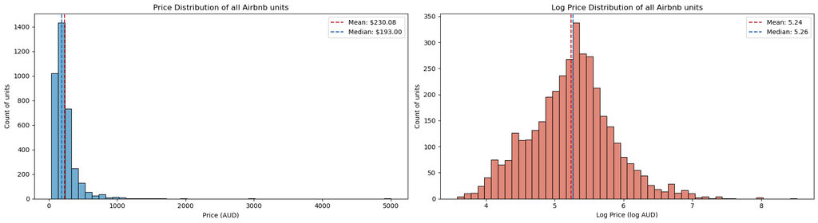

```python
# Distribution plot for price and log price
plot_data = train_df[train_df['price'].notna()]

fig, (ax1, ax2) = plt.subplots(1, 2, figsize=(18, 5))

# Left: Price distribution
sns.histplot(data=plot_data, x='price', bins=50, color='#4393C3', ax=ax1)
ax1.axvline(plot_data['price'].mean(),
           color='#B2182B', linestyle='--', linewidth=1.5,
           label=f"Mean: ${plot_data['price'].mean():.2f}")
ax1.axvline(plot_data['price'].median(),
           color='#2166AC', linestyle='--', linewidth=1.5,
           label=f"Median: ${plot_data['price'].median():.2f}")
ax1.set_title('Price Distribution of all Airbnb units')
ax1.set_xlabel('Price (AUD)')
ax1.set_ylabel('Count of units')
ax1.legend()

# Right: Log price distribution
log_price = np.log(plot_data['price'])
sns.histplot(log_price, bins=50, color='#D6604D', ax=ax2)
ax2.axvline(log_price.mean(),
           color='#B2182B', linestyle='--', linewidth=1.5,
           label=f"Mean: {log_price.mean():.2f}")
ax2.axvline(log_price.median(),
           color='#2166AC', linestyle='--', linewidth=1.5,
           label=f"Median: {log_price.median():.2f}")
ax2.set_title('Log Price Distribution of all Airbnb units')
ax2.set_xlabel('Log Price (log AUD)')
ax2.set_ylabel('Count of units')
ax2.legend()

plt.tight_layout()
```

**2. Minimum Nights**

The mean minimum nights is 4.0, while the median is only 2.0, and the mode falls at 1 night. The large gap between mean and median indicates that a small number of listings with very high minimum night requirements are pulling the average upward, while the typical host requires just 1-2 nights minimum stay.

The standard deviation of 15.3 is nearly 4 times the mean, reflecting extreme variability. The range spans from 1 to 500 nights, an extraordinarily wide spread. The IQR of just 2 nights (Q1=1, Q3=3) confirms that the central 50% of listings cluster tightly around very short minimum stays, while the outliers in the upper tail are extreme.

The histogram reveals an extremely right-skewed distribution, with the vast majority of listings concentrated within the lowest minimum-night categories and only a small number of observations extending into the upper tail. This is one of the most extreme cases of right skew in the dataset, suggesting the presence of a small but distinct group of hosts who use Airbnb for medium to long-term rentals rather than short-term stays.

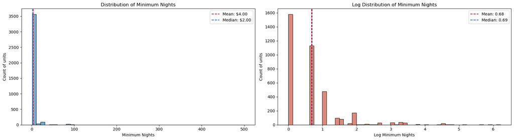

```python
# Distribution plot for minimum nights and log minimum nights
plot_data = train_df[train_df['minimum_nights'].notna()]

fig, (ax1, ax2) = plt.subplots(1, 2, figsize=(18, 5))

# Left: Minimum night original distribution
sns.histplot(data=plot_data, x='minimum_nights', bins=50, color='#4393C3', ax=ax1)
ax1.axvline(plot_data['minimum_nights'].mean(),
           color='#B2182B', linestyle='--', linewidth=1.5,
           label=f"Mean: ${plot_data['minimum_nights'].mean():.2f}")
ax1.axvline(plot_data['minimum_nights'].median(),
           color='#2166AC', linestyle='--', linewidth=1.5,
           label=f"Median: ${plot_data['minimum_nights'].median():.2f}")
ax1.set_title('Distribution of Minimum Nights')
ax1.set_xlabel('Minimum Nights')
ax1.set_ylabel('Count of units')
ax1.legend()

# Right: Log minimum nights distribution
log_price = np.log(plot_data['minimum_nights'])
sns.histplot(log_price, bins=50, color='#D6604D', ax=ax2)
ax2.axvline(log_price.mean(),
           color='#B2182B', linestyle='--', linewidth=1.5,
           label=f"Mean: {log_price.mean():.2f}")
ax2.axvline(log_price.median(),
           color='#2166AC', linestyle='--', linewidth=1.5,
           label=f"Median: {log_price.median():.2f}")
ax2.set_title('Log Distribution of Minimum Nights')
ax2.set_xlabel('Log Minimum Nights')
ax2.set_ylabel('Count of units')
ax2.legend()

plt.tight_layout()
```

**3. Room Type**

Room type is a categorical variable, so the appropriate measure of central tendency is the mode. The mode is Entire home/apt, which is by far the most frequently occurring category with approximately 2,800 listings (~75% of all listings).

- `Entire home/apt`: around 2,800 listings (~75%)
- `Private room`: around 880 listings (~24%)
- `Shared room`: around 30 listings (<1%)
- `Hotel room`: around 25 listings (<1%)

The distribution is highly imbalanced where Entire home/apt and Private room together account for nearly 99% of all listings, while Shared room and Hotel room are negligible. This extreme concentration in two categories indicates very low diversity in room type across the dataset.

The bar chart shows a distribution that is heavily concentrated in a small number of categories. Listing counts decline sharply from Entire home/apt to Private room and then fall to near zero for Shared room and Hotel room. This pattern reflects a market dominated by whole-property and private-room accommodation.

The dominance of Entire home/apt (~75%) reflects Brisbane's Airbnb market structure, where most hosts rent out whole properties rather than individual rooms. In contrast, Private rooms represent a smaller but still significant segment of the market, while Shared rooms and Hotel rooms account for only a very small proportion of listings. Overall, the distribution highlights a strong preference for independent accommodation among both hosts and guests in Brisbane.

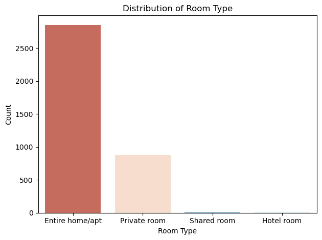

```python
# Count variable distribution for Room Type
order = train_df['room_type'].value_counts().index
sns.countplot(data=train_df, x='room_type', order=order, hue='room_type',
              palette='RdBu', legend=False)
plt.title('Distribution of Room Type')
plt.xlabel('Room Type')
plt.ylabel('Count')
plt.tight_layout()
plt.savefig('room_type.png', dpi=150, bbox_inches='tight')
plt.show()
```

**4. Neighbourhood**

As a categorical variable, the mode is Brisbane City, which has the highest listing count at approximately 560 listings - nearly twice the count of the second-ranked neighbourhood, South Brisbane (~310 listings).

The bar chart reveals a highly concentrated distribution, with listing counts declining rapidly beyond the top three neighbourhoods.

The strong geographic concentration in inner-city neighbourhoods reflects the demand-driven nature of Airbnb accommodation. Tourists and business travellers are more likely to prefer central locations with convenient access to the CBD, entertainment precincts, restaurants, and public transport. The dominance of Brisbane City, South Brisbane, and Fortitude Valley suggests that Airbnb activity is concentrated in areas with high visitor demand, while outer suburbs such as Sunnybank and Rocklea-Acacia Ridge contain comparatively fewer listings.

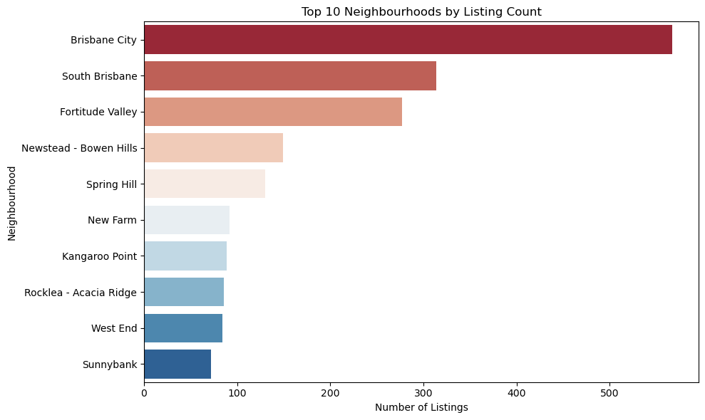

```python
# Bar chart for Neighbourhood
plt.figure(figsize=(10, 6))
top10 = train_df['neighbourhood_cleansed'].value_counts().head(10)
sns.barplot(x=top10.values, y=top10.index,
            hue=top10.index, palette='RdBu', legend=False)
plt.title('Top 10 Neighbourhoods by Listing Count')
plt.xlabel('Number of Listings')
plt.ylabel('Neighbourhood')
plt.tight_layout()
plt.show()
```

**5. Availability (365 days)**

The mean availability is 198.4 days and the median is 192 days, indicating that on average, listings are available for just over half the year. The mean and median are relatively close, suggesting that unlike price and minimum nights, this variable does not have extreme outliers pulling the mean in one direction. The highest concentration of observations occurs in the 330-365 day range, indicating that many hosts keep their listings available for most of the year.

The histogram reveals a clearly bimodal distribution - there are *two distinct peaks*: one around 0-75 days and another, larger peak around 300-365 days, with a noticeable trough in the 175-250 day range. This bimodal pattern is unusual and indicates that the dataset contains two fundamentally different types of hosts rather than a single homogeneous population. The larger peak around 330–365 days suggests that a substantial proportion of hosts maintain near year-round availability.

The bimodal distribution highlights two distinct hosting strategies within the Brisbane Airbnb market. Some hosts appear to make their properties available only occasionally, possibly during peak travel periods or when temporarily away from home. In contrast, another large group maintains near year-round availability, suggesting a more commercial or professional approach to hosting.

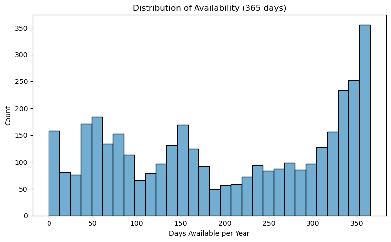

```python
# Histogram for Avalability
plt.figure(figsize=(8, 5))
sns.histplot(train_df['availability_365'], bins=30, color='#4393C3')
plt.title('Distribution of Availability (365 days)')
plt.xlabel('Days Available per Year')
plt.ylabel('Count')
plt.tight_layout()
plt.savefig('availability.png', dpi=150, bbox_inches='tight')
plt.show()
```

**6. Number of Reviews**

The mean number of reviews is 50.6, while the median is only 18 and the mode falls in the 0-25 range. The large gap between mean (50.6) and median (18) - nearly three times - indicates that a small number of highly active listings with hundreds of reviews are pulling the average upward significantly, while the typical listing has accumulated far fewer reviews.

The standard deviation of 90.08 is nearly five times the median, reflecting extreme variability across listings. The range spans from 0 to 1,130 reviews - an enormous spread. The IQR of 52 reviews (Q1=4, Q3=56) confirms that the central 50% of listings have between 4 and 56 reviews, while the upper tail extends dramatically to 1,130. This extreme dispersion suggests the presence of a small number of very popular, long-established listings that have accumulated reviews over many years.

The histogram shows one of the most strongly right-skewed distributions in the dataset. Even with the x-axis limited to 200 reviews, over 2,000 listings fall within the first bin (0-25 reviews), with counts dropping sharply thereafter. The distribution has a very steep left peak and a long, gradually declining right tail - a classic exponential decay shape. The true maximum of 1,130 reviews lies far beyond the visible range, highlighting the extreme concentration at low values.

The concentration of listings with fewer than 25 reviews suggests that the Brisbane Airbnb market is characterised by many relatively new or less frequently booked properties. Conversely, the small number of listings with exceptionally high review counts indicates a group of established listings that have maintained strong occupancy over long periods. The large disparity between these groups highlights considerable variation in listing popularity and host experience across the market.

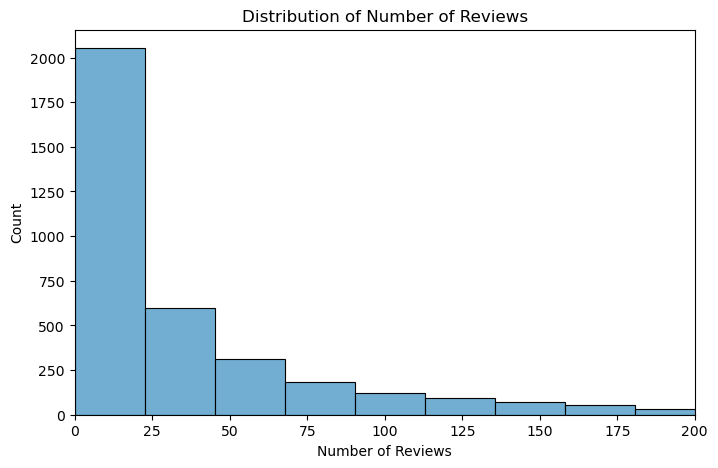

```python
# Histogram for Number of Review
plt.figure(figsize=(8, 5))
sns.histplot(train_df['number_of_reviews'], bins=50, color='#4393C3')
plt.title('Distribution of Number of Reviews')
plt.xlabel('Number of Reviews')
plt.ylabel('Count')
plt.xlim(0, 200)
plt.show()
```

**7. Accommodates**

The mean number of guests accommodated is 3.70, the median is 3, and the mode is 2 - the most frequently occurring value with approximately 1,430 listings. The mode being lower than both mean and median indicates that while 2-guest listings dominate, larger properties pull the average upward.

The standard deviation of 2.31 indicates moderate spread around the mean. The range spans from 1 to 16 guests, reflecting a diverse mix of small studio apartments and large group properties. The IQR of 2 guests (Q1=2, Q3=4) is relatively narrow, confirming that the central 50% of listings accommodate between 2 and 4 guests - a tight cluster despite the wide overall range.

The histogram reveals a multimodal distribution with distinct peaks at 2, 4, and 6 guests. This is not a simple right-skewed distribution - instead, counts spike at even numbers (2, 4, 6, 8) and dip at odd numbers (3, 5, 7), creating a sawtooth pattern. This reflects the practical reality that most properties are designed for couples (2), families of 4, or groups of 6, making even-numbered capacities far more common than odd. Beyond 8 guests, counts drop sharply with a long right tail extending to 16.

The concentration of listings at 2 and 4 guests aligns with the dominance of Entire home/apt and Private room types observed in the room type analysis - most Brisbane Airbnb listings cater to couples or small families. The sawtooth pattern at even numbers is a practically meaningful finding that reflects how hosts configure their properties. The small number of listings accommodating more than 10 guests represent a niche high-capacity segment within the Brisbane Airbnb market. Their relatively low frequency suggests that demand is primarily concentrated among couples, solo travellers, and small families rather than large groups.

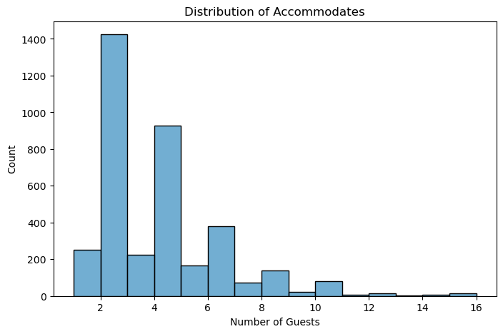

```python
# Histogram for Accomodates
plt.figure(figsize=(8,5))
sns.histplot(train_df['accommodates'], bins=15, color='#4393C3')
plt.title('Distribution of Accommodates')
plt.xlabel('Number of Guests')
plt.ylabel('Count')
plt.show()
```

**8. Bathrooms**

- The mean number of bathrooms is 1.42, the median is 1, and the mode is also 1 - with approximately 2,350 listings having exactly 1 bathroom.
- The mean being slightly higher than the median indicates a modest right skew caused by a small number of properties with many bathrooms pulling the average upward.
- The standard deviation of 0.71 is relatively low compared to other variables

==> Indicating that most listings cluster tightly around 1-2 bathrooms.

- The range spans from 0 to 9 bathrooms, though values above 4 are extremely rare.
- The IQR of 1 bathroom (Q1=1, Q3=2) confirms that 75% of all listings have either 1 or 2 bathrooms - very little variability in the central distribution despite the wide overall range.

The histogram shows a strongly right-skewed distribution

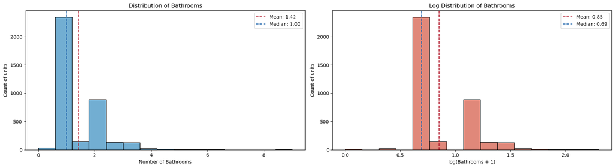

```python
fig, (ax1, ax2) = plt.subplots(1, 2, figsize=(18, 5))

# Left: Original distribution
plot_data = train_df[train_df['bathrooms'].notna()]
sns.histplot(data=plot_data, x='bathrooms', bins=15, color='#4393C3', ax=ax1)
ax1.axvline(plot_data['bathrooms'].mean(),
            color='#B2182B', linestyle='--', linewidth=1.5,
            label=f"Mean: {plot_data['bathrooms'].mean():.2f}")
ax1.axvline(plot_data['bathrooms'].median(),
            color='#2166AC', linestyle='--', linewidth=1.5,
            label=f"Median: {plot_data['bathrooms'].median():.2f}")
ax1.set_title('Distribution of Bathrooms')
ax1.set_xlabel('Number of Bathrooms')
ax1.set_ylabel('Count of units')
ax1.legend()

# Right: Log transformed (log1p vì min = 0)
log_bathrooms = np.log1p(plot_data['bathrooms'])
sns.histplot(log_bathrooms, bins=15, color='#D6604D', ax=ax2)
ax2.axvline(log_bathrooms.mean(),
            color='#B2182B', linestyle='--', linewidth=1.5,
            label=f"Mean: {log_bathrooms.mean():.2f}")
ax2.axvline(log_bathrooms.median(),
            color='#2166AC', linestyle='--', linewidth=1.5,
            label=f"Median: {log_bathrooms.median():.2f}")
ax2.set_title('Log Distribution of Bathrooms')
ax2.set_xlabel('log(Bathrooms + 1)')
ax2.set_ylabel('Count of units')
ax2.legend()

plt.tight_layout()
```

**9. Review Scores Rating**

- The mean review score is 4.74 and the median is 4.83, both falling very close to the maximum possible score of 5.0.

==> Notably, the median is higher than the mean, indicating a left-skewed distribution where a small number of poorly rated listings pull the average downward.

- The standard deviation of 0.37 is extremely low relative to the scale of 1-5, indicating that the vast majority of listings cluster tightly in the upper range.
- The range spans from 1.0 to 5.0, but this full range is misleading
- The IQR of just 0.28 (Q1=4.67, Q3=4.95) reveals that the central 50% of listings are compressed into a very narrow band near the top of the scale.
- The variance of 0.14 is the smallest of all numerical variables analysed, confirming minimal spread.

==> The histogram shows a strongly left-skewed (negatively skewed) distribution ==> the opposite of most other variables in this dataset.

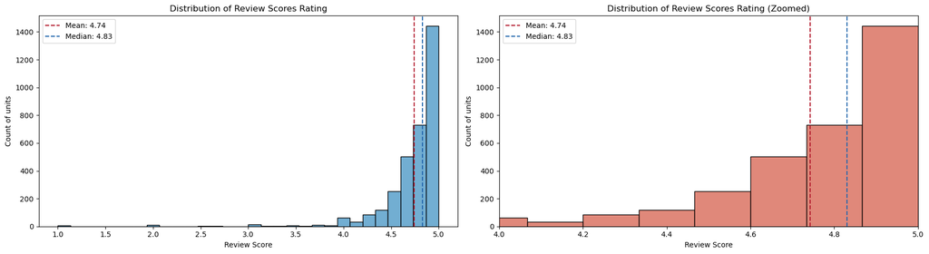

```python
# Histogram for Review Score Rating
fig, axes = plt.subplots(1, 2, figsize=(18, 5))

# Left: Original distribution
plot_data = train_df[train_df['review_scores_rating'].notna()]
sns.histplot(plot_data['review_scores_rating'], bins=30,
             color='#4393C3', ax=axes[0])
axes[0].axvline(plot_data['review_scores_rating'].mean(),
                color='#B2182B', linestyle='--', linewidth=1.5,
                label=f"Mean: {plot_data['review_scores_rating'].mean():.2f}")
axes[0].axvline(plot_data['review_scores_rating'].median(),
                color='#2166AC', linestyle='--', linewidth=1.5,
                label=f"Median: {plot_data['review_scores_rating'].median():.2f}")
axes[0].set_title('Distribution of Review Scores Rating')
axes[0].set_xlabel('Review Score')
axes[0].set_ylabel('Count of units')
axes[0].legend()

# Right: Zoomed in (4.0 - 5.0) để thấy rõ phân phối chính
sns.histplot(plot_data['review_scores_rating'], bins=30,
             color='#D6604D', ax=axes[1])
axes[1].axvline(plot_data['review_scores_rating'].mean(),
                color='#B2182B', linestyle='--', linewidth=1.5,
                label=f"Mean: {plot_data['review_scores_rating'].mean():.2f}")
axes[1].axvline(plot_data['review_scores_rating'].median(),
                color='#2166AC', linestyle='--', linewidth=1.5,
                label=f"Median: {plot_data['review_scores_rating'].median():.2f}")
axes[1].set_title('Distribution of Review Scores Rating (Zoomed)')
axes[1].set_xlabel('Review Score')
axes[1].set_ylabel('Count of units')
axes[1].set_xlim(4.0, 5.0)
axes[1].legend()

plt.tight_layout()
plt.show()
```

**10. Host Listings Count**

- The mean host listings count is 50.07, while the median is only 5 and the mode falls in the lowest bin (1-25 listings).
- The enormous gap between mean (50.07) and median (5) ~ a ratio of 10:1

==> This is one of the most extreme disparities observed across all variables in this dataset, indicating that a very small number of hosts with hundreds of listings are dramatically inflating the average.

- The standard deviation of 111.88 is more than twice the mean, reflecting extraordinary variability.
- The range spans from 1 to 702 listings - an almost 700-fold difference between the smallest and largest host portfolios.
- The IQR of 31 listings (Q1=1, Q3=32) confirms that 75% of hosts manage fewer than 32 listings, while the upper 25% includes hosts ranging from 32 to 702 listings.

==> This extreme spread highlights the coexistence of two fundamentally different types of market participants.

- The extreme right skew and the large gap between the mean and median reveal a highly concentrated market structure within Brisbane’s Airbnb ecosystem.

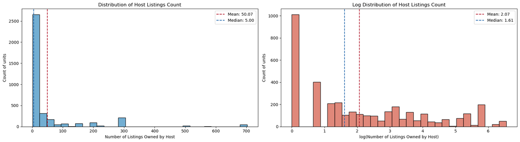

```python
fig, axes = plt.subplots(1, 2, figsize=(18, 5))

# Left: Original distribution
plot_data = train_df[train_df['host_listings_count'].notna()]
sns.histplot(plot_data['host_listings_count'], bins=30,
             color='#4393C3', ax=axes[0])
axes[0].axvline(plot_data['host_listings_count'].mean(),
                color='#B2182B', linestyle='--', linewidth=1.5,
                label=f"Mean: {plot_data['host_listings_count'].mean():.2f}")
axes[0].axvline(plot_data['host_listings_count'].median(),
                color='#2166AC', linestyle='--', linewidth=1.5,
                label=f"Median: {plot_data['host_listings_count'].median():.2f}")
axes[0].set_title('Distribution of Host Listings Count')
axes[0].set_xlabel('Number of Listings Owned by Host')
axes[0].set_ylabel('Count of units')
axes[0].legend()

# Right: Log transformed
log_host = np.log(plot_data['host_listings_count'])
sns.histplot(log_host, bins=30,
             color='#D6604D', ax=axes[1])
axes[1].axvline(log_host.mean(),
                color='#B2182B', linestyle='--', linewidth=1.5,
                label=f"Mean: {log_host.mean():.2f}")
axes[1].axvline(log_host.median(),
                color='#2166AC', linestyle='--', linewidth=1.5,
                label=f"Median: {log_host.median():.2f}")
axes[1].set_title('Log Distribution of Host Listings Count')
axes[1].set_xlabel('log(Number of Listings Owned by Host)')
axes[1].set_ylabel('Count of units')
axes[1].legend()

plt.tight_layout()
plt.show()
```

**11. Property Type**

- Entire rental unit: 54.2%
- Entire home: 17.9%
- Private room in home: 15.4%
- Private room in rental unit: 5.9%
- Entire guest suite: 3.7%
- Entire serviced apartment: 2.9%

The pie chart shows a highly imbalanced distribution - Entire rental unit dominates with more than half the market share, while Entire serviced apartments (2.9%) and Entire guest suites (3.7%) represent relatively small segments of the market. The sharp drop from 54.2% to 17.9% between the top two categories confirms the dominance of rental units in Brisbane's Airbnb market.

The dominance of Entire rental units (54.2%) reflects Brisbane’s urban housing landscape, where apartment-style accommodation forms a major component of the Airbnb market. Entire homes represent a substantial secondary segment and are likely associated with suburban residential areas, while private rooms reflect the traditional sharing-economy model where hosts rent spare rooms within occupied properties. The relatively small proportions of guest suites and serviced apartments indicate that these property types occupy niche positions within the Brisbane Airbnb market. Overall, the distribution suggests that independent accommodation is strongly preferred over shared living arrangements.

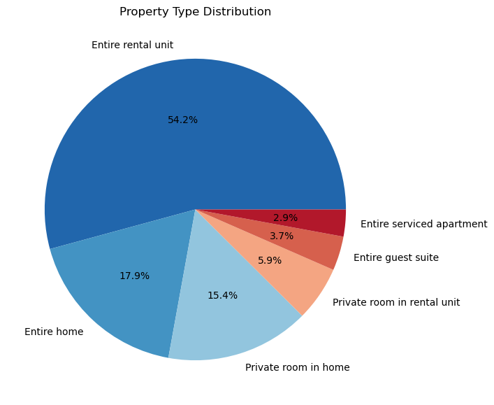

```python
# Pie char for categorical Property Type
property_counts = train_df['property_type'].value_counts().head(6)
rdbu_colors = ['#2166AC', '#4393C3', '#92C5DE', '#F4A582', '#D6604D', '#B2182B']

plt.figure(figsize=(7,7))
plt.pie(property_counts,
        labels=property_counts.index,
        colors=rdbu_colors,
        autopct='%1.1f%%')
plt.title('Property Type Distribution')
plt.show()
```

**CONCLUSION**

The univariate analysis reveals several important patterns within the Brisbane Airbnb dataset. Numerical variables such as price, minimum_nights, number_of_reviews, and host_listings_count exhibit strong positive skewness and contain extreme values, indicating substantial heterogeneity across listings and hosts. In contrast, review_scores_rating is negatively skewed and tightly concentrated near the maximum rating, reflecting consistently high levels of guest satisfaction. The availability_365 variable displays a distinctive bimodal distribution, suggesting the presence of different hosting strategies within the market. The categorical variables show that Airbnb activity is concentrated in inner-city neighbourhoods and is dominated by entire-property accommodation. Overall, these findings provide valuable insights into the structure, diversity, and characteristics of Brisbane’s Airbnb market.

#### 5. Feature Analysis and Selection

**Table 1. Classification of Selected Original Features**

| Variable Type | Number of Features | Feature Names |
| --- | --- | --- |
| Numerical (continuous) | 13 | `bathrooms`, `estimated_occupancy_l365d`, `review_scores_rating`, `review_scores_accuracy`, `review_scores_cleanliness`, `review_scores_checkin`, `review_scores_communication`, `review_scores_location… |
| Numerical (discrete) | 11 | `accommodates`, `bedrooms`, `beds`, `minimum_nights`, `maximum_nights`, `availability_30`, `availability_365`, `number_of_reviews`, `number_of_reviews_ltm`, `number_of_reviews_l30d`, `host_listings_co… |
| Categorical (nominal) | 6 | `room_type`, `property_type`, `neighbourhood_cleansed`, `amenities`, `host_response_time`, `name` |
| Categorical (ordinal) | 1 | `host_response_time` ` |
| Boolean | 3 | `host_is_superhost`, `instant_bookable`, `host_identity_verified` |
| Date | 2 | `host_since`, `last_review` |

```python
# Define desired features here
# Continuous features
num_features = [
   'bathrooms', 'estimated_occupancy_l365d', 'review_scores_rating', 'review_scores_accuracy',
    'review_scores_cleanliness', 'review_scores_checkin', 'review_scores_communication', 'review_scores_location', 'review_scores_value',
    'reviews_per_month', 'calculated_host_listings_count', 'latitude', 'longitude',
    'accommodates', 'bedrooms', 'beds', 'minimum_nights', 'maximum_nights', 'availability_30', 'availability_365',
    'number_of_reviews', 'number_of_reviews_ltm', 'number_of_reviews_l30d', 'host_listings_count'

]
# Categorical features
cat_features  = ['room_type', 'property_type', 'neighbourhood_cleansed','amentities', 'host_response _time', 'name']
# Boolean features
bool_features = ['host_is_superhost', 'instant_bookable', 'host_identity_verified']
# Date features
date_features = ['host_since', 'last_review']
```

**Table 2. Classification of Final Features Used for Modelling**

| Variable Type | Count | Feature Names |
| --- | --- | --- |
| Numerical (continuous) | 19 | `bathrooms`, `estimated_occupancy_l365d`, `review_scores_rating`, `review_scores_accuracy`, `review_scores_cleanliness`, `review_scores_checkin`, `review_scores_communication`, `review_scores_location… |
| Numerical (discrete) | 10 | `accommodates`, `bedrooms`, `beds`, `minimum_nights`, `maximum_nights`, `availability_30`, `availability_365`, `number_of_reviews`, `number_of_reviews_ltm`, `number_of_reviews_l30d` |
| Categorical (nominal) | 5 | `room_type`, `property_type`, `neighbourhood_cleansed`, `amenities`, `host_response_time` |
| Categorical (ordinal) | 1 | `host_response_time` |
| Boolean | 38 | `host_is_superhost`, `instant_bookable`, `host_identity_verified`, `is_commercial_host`, (from *amenities* bucket): `has_wifi`, `has_smoke_alarm`, `has_kitchen`, `has_washer`, `has_tv`, `has_hot_water… |
| Engineered | 42 | `amenities_count` (from `amenities`), `host_experience_days` (from `host_since`), `days_since_last_review` (from`last_review`), `is_commercial_host` (from `host_listing_count`), `beds_per_person` (fro… |

**Before selecting meaningful features, variables that provide little or no predictive value were removed.**

- Identifier and Personal Information Variables (`ID`, `host_id`, `host_name`):

Were removed because they function primarily as identifiers rather than meaningful property characteristics. These variables do not provide information about listing quality, location, capacity, or host behaviour and therefore are unlikely to contribute useful predictive information.

- Free-text Variables (`description`, `neighborhood_overview`, `host_about`):

Were excluded because they contain unstructured textual information that would require natural language processing techniques to extract meaningful signals. Since the focus of this project is on structured data modelling, these variables were not considered further.

- Location-related Variables (`host_location`, `host_neighbourhood`):

Were removed due to inconsistent formatting, substantial missingness, and overlap with neighbourhood_cleansed, which provides a cleaner and more standardised representation of listing location.

- Administrative and Platform Metadata Variables (`source`, `host_verifications`):

Were excluded because they primarily contain platform-level information rather than direct property characteristics. In addition, host_verifications consists of complex multi-category text values that would require additional feature engineering before being suitable for modelling.

- Duplicate information column (`bathrooms_text`):

This variable contains a textual representation of the number of bathrooms (e.g., "1 bath", "2 baths"), which duplicates the information already captured in the numerical `bathrooms` variable. Since the numeric version is more suitable for statistical analysis and modelling, `bathrooms_text` was excluded to avoid redundancy.

- Revenue Variable (`estimated_revenue_l365d`):

`estimated_revenue_l365d` is removed due to concerns regarding **target leakage**. This variable is calculated using listing price, which is the target variable that the model is trying to predict. As a result, information from the target is already embedded within the feature itself. If `estimated_revenue_l365d` were included in the model, the model could partially infer the value of `price` from a variable that was directly derived from it, rather than learning genuine relationships between price and listing characteristics such as location, property type, capacity, and host behaviour. Consequently, the model's performance may appear better than it actually is, as it is effectively being given access to information related to the answer. In contrast, `estimated_occupancy_l365d` was retained because it captures booking demand without directly incorporating the target variable.

```python
# Remove text/descriptive columns that add no signal
# NOTE: 'name' is kept here — keyword flags are extracted from it in the feature engineering step
features_to_drop = [
    'description', 'neighborhood_overview', 'host_name', 'host_id',
    'host_about', 'host_location', 'host_neighbourhood', 'host_verifications',
    'bathrooms_text'
]
train_data = raw_train_df.drop(columns=[c for c in features_to_drop if c in raw_train_df.columns])
test_data  = raw_test_df.drop( columns=[c for c in features_to_drop if c in raw_test_df.columns])
```

```python
print(train_data['estimated_revenue_l365d'].describe())
print(f"\nMissing: {train_data['estimated_revenue_l365d'].isnull().sum()}")
print(f"Min: {train_data['estimated_revenue_l365d'].min()}")
print(f"Max: {train_data['estimated_revenue_l365d'].max()}")
```

```
count      3735.000000
mean      19195.382329
std       24953.948212
min           0.000000
25%        2280.000000
50%       10962.000000
75%       28560.000000
max      426615.000000
Name: estimated_revenue_l365d, dtype: float64

Missing: 0
Min: 0.0
Max: 426615.0
```

```python
# Check statistically numeric features of desire
train_data[num_features].describe()
```

|  | bathrooms | estimated_occupancy_l365d | review_scores_rating | review_scores_accuracy | review_scores_cleanliness | review_scores_checkin | review_scores_communication | review_scores_location | review_scores_value | reviews_per_month | ... | bedrooms | beds | minimum_nights | maximum_nights | availability_30 | availability_365 | number_of_reviews | number_of_reviews_ltm | number_of_reviews_l30d | host_listings_count |
| --- | --- | --- | --- | --- | --- | --- | --- | --- | --- | --- | --- | --- | --- | --- | --- | --- | --- | --- | --- | --- | --- |
| count | 3730.000000 | 3735.000000 | 3298.00000 | 3298.000000 | 3298.000000 | 3298.000000 | 3298.000000 | 3298.00000 | 3298.000000 | 3298.000000 | ... | 3733.000000 | 3732.000000 | 3735.000000 | 3735.000000 | 3735.000000 | 3735.000000 | 3735.000000 | 3735.000000 | 3735.000000 | 3733.000000 |
| mean | 1.424129 | 91.639893 | 4.74248 | 4.782016 | 4.725891 | 4.782502 | 4.840088 | 4.81124 | 4.687784 | 2.084297 | ... | 1.758639 | 2.117899 | 3.999732 | 420.077108 | 12.070147 | 198.401339 | 50.595448 | 15.959036 | 1.375904 | 50.068042 |
| std | 0.705594 | 87.603878 | 0.36693 | 0.346275 | 0.363493 | 0.329452 | 0.307827 | 0.29165 | 0.382292 | 1.808557 | ... | 1.110403 | 1.577968 | 15.296805 | 369.841373 | 9.028575 | 119.506895 | 90.078291 | 19.642907 | 1.909735 | 111.875072 |
| min | 0.000000 | 0.000000 | 1.00000 | 1.000000 | 1.000000 | 1.000000 | 1.000000 | 1.00000 | 1.000000 | 0.010000 | ... | 0.000000 | 0.000000 | 1.000000 | 1.000000 | 0.000000 | 0.000000 | 0.000000 | 0.000000 | 0.000000 | 1.000000 |
| 25% | 1.000000 | 12.000000 | 4.67000 | 4.720000 | 4.640000 | 4.710000 | 4.810000 | 4.76000 | 4.600000 | 0.770000 | ... | 1.000000 | 1.000000 | 1.000000 | 90.000000 | 4.000000 | 83.000000 | 4.000000 | 2.000000 | 0.000000 | 1.000000 |
| 50% | 1.000000 | 66.000000 | 4.83000 | 4.870000 | 4.820000 | 4.880000 | 4.930000 | 4.89000 | 4.770000 | 1.640000 | ... | 1.000000 | 2.000000 | 2.000000 | 365.000000 | 11.000000 | 192.000000 | 18.000000 | 9.000000 | 1.000000 | 5.000000 |
| 75% | 2.000000 | 156.000000 | 4.95000 | 4.970000 | 4.950000 | 4.980000 | 5.000000 | 4.97000 | 4.900000 | 2.947500 | ... | 2.000000 | 3.000000 | 3.000000 | 365.000000 | 19.000000 | 322.000000 | 56.000000 | 23.000000 | 2.000000 | 32.000000 |
| max | 9.000000 | 255.000000 | 5.00000 | 5.000000 | 5.000000 | 5.000000 | 5.000000 | 5.00000 | 5.000000 | 13.620000 | ... | 9.000000 | 24.000000 | 500.000000 | 1125.000000 | 30.000000 | 365.000000 | 1130.000000 | 181.000000 | 16.000000 | 702.000000 |

8 rows × 24 columns

#### The relationship between features and price

**1. Numerical analysis**

**a. Heatmap using Pearson method**

```python
# Price has "$" and "," and it is a object -> need to remove the signs & change to float
train_data['price_original'] = train_data['price']

# Create a cleaned version for analysis
train_data['price_clean'] = (
    train_data['price']
    .str.replace(r'[$,]', '', regex=True)
    .astype(float)
)

print(train_data[['price_original', 'price_clean']].head())
```

```
  price_original  price_clean
0         $97.00         97.0
1        $205.00        205.0
2        $186.00        186.0
3        $157.00        157.0
4        $300.00        300.0
```

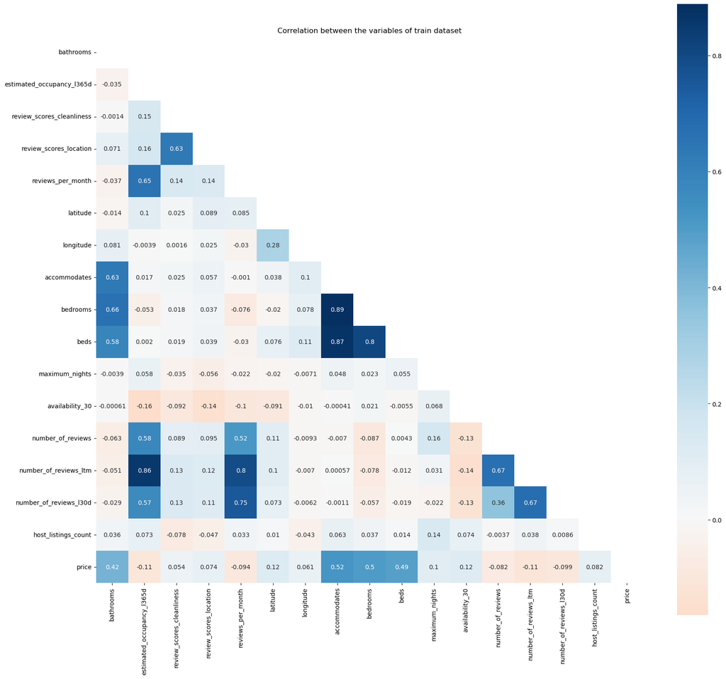

```python
features = train_data[num_features]
fea = pd.get_dummies(features)

fea['price'] = train_data['price_clean']

corr = fea.corr(method='pearson')

corr_no_diag = corr.copy()
np.fill_diagonal(corr_no_diag.values, 0)

price_corr = corr_no_diag['price'].abs() > 0.05
filtered_cols = price_corr[price_corr].index.tolist()

if 'price' not in filtered_cols:
    filtered_cols.append('price')

corr_filtered = corr.loc[filtered_cols, filtered_cols]

mask = np.zeros_like(corr_filtered, dtype=np.bool_)
mask[np.triu_indices_from(mask)] = True

f, ax = plt.subplots(figsize=(20, 18))

sns.heatmap(
    corr_filtered,
    annot=True,
    mask=mask,
    center=0,
    square=True,
    cmap='RdBu',
    xticklabels='auto',
)

plt.title('Correlation between the variables of train dataset')
```

**Numerical Feature Analysis - Correlation with Price**

- Pearson correlation was used to measure the linear relationship between each numerical feature and price. Only features with

|correlation| > 0.05 with price are retained in the heatmap to reduce visual noise.

**Must-select features (|corr| > 0.2):**

- Must-selected(abs(corr)>0.2): `accommodates`, `bathrooms`, `bedrooms`, `beds`
- These physical capacity variables show the clearest positive relationship with price — listings that can accommodate more guests, with more bedrooms and bathrooms, consistently command higher nightly rates. This is intuitive: larger properties require more infrastructure and offer more value to guests, justifying premium pricing.

**Consider features (|corr| > 0.1):**

- Consider (abs(corr)>0.1): `maximum_nights`, `availability_30`, `number_of_reviews_ltm`, `estimated_occupancy_l365d`.
- Although their individual correlations are considerably lower than those of the capacity-related variables, they capture aspects of listing availability, booking activity, and occupancy patterns that may provide additional predictive value when considered alongside other features.

**Other observations from the heatmap:**

- Several features show high inter-correlation with each other

rather than with price:

[output not shown]

- A low Pearson correlation with price does not necessarily mean a feature should be excluded because there are some non-linear relationship between them.

  **Review Score**
  - Features such as `review_scores_cleanliness`, `review_scores_location` and `estimated_occupancy_l365d` show weak linear correlations but may still capture non-linear relationships with price or provide useful information when combined with other predictors. Therefore, both statistical evidence and domain knowledge were considered when selecting the final set of features.

A scatterplot matrix was constructed using the selected numerical features to further explore relationships among predictors and identify potential multicollinearity.

- **Size features are strongly correlated** — `accommodates`, `bedrooms`, `bathrooms`, and `beds` rise together
- **Occupancy drives reviews** — a positive association between `number_of_reviews_ltm` and `estimated_occupancy_l365d` shows that higher-occupancy listings tend to collect more reviews
- **Availability and limits are weak, dispersed predictors** — `availability_30` and `maximum_nights` show weaker, scattered relationships with price and the other features.

Overall, the scatterplot matrix supports the findings from the correlation analysis while providing additional insight into relationships among the predictors themselves. Even though no clear linear pattern, they reflect host availability and booking restrictions that may still influence pricing and booking performance.

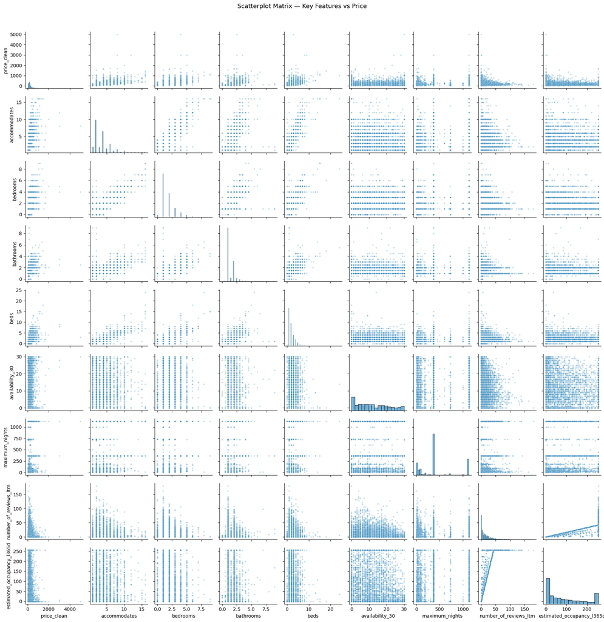

```python
# Scatter plox - finding relationship between price and key features
key_features = ['price_clean', 'accommodates', 'bedrooms', 'bathrooms', 'beds',
                'availability_30', 'maximum_nights',  'number_of_reviews_ltm', 'estimated_occupancy_l365d']

plot_data = train_data[key_features].dropna()

sns.pairplot(plot_data,
             diag_kind='hist',
             plot_kws={'alpha': 0.3, 's': 10, 'color': '#4393C3'},
             diag_kws={'color': '#4393C3'},
             height=2)

plt.suptitle('Scatterplot Matrix — Key Features vs Price',
             y=1.02, fontsize=13)
plt.tight_layout()
plt.show()
```

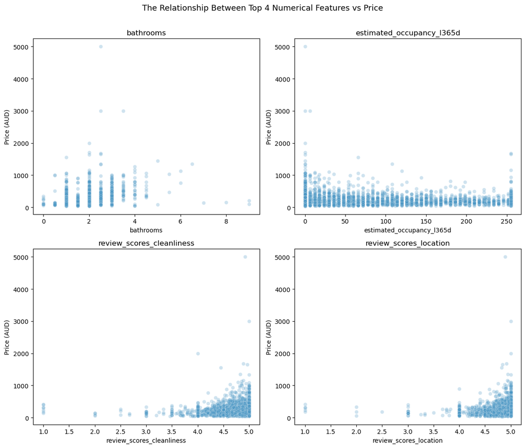

```python
# Top 4 scatter plot
top4 = price_corr.abs().nlargest(4).index.tolist()

fig, axes = plt.subplots(2, 2, figsize=(12, 10))
for ax, feat in zip(axes.flatten(), top4):
    sns.scatterplot(data=train_data, x=feat, y='price_clean', alpha=0.25,
                    color='#4393C3', ax=ax)
    ax.set_title(f'{feat}')
    ax.set_xlabel(feat)
    ax.set_ylabel('Price (AUD)')
plt.suptitle('The Relationship Between Top 4 Numerical Features vs Price', y=1.01, fontsize=13)
plt.tight_layout()
plt.show()
```

**2. Categorical Feature Analysis**

> Box plots were used to examine how categorical features relate to price, with median price used as the central measure due to the right-skewed distribution of price observed in Question 4.

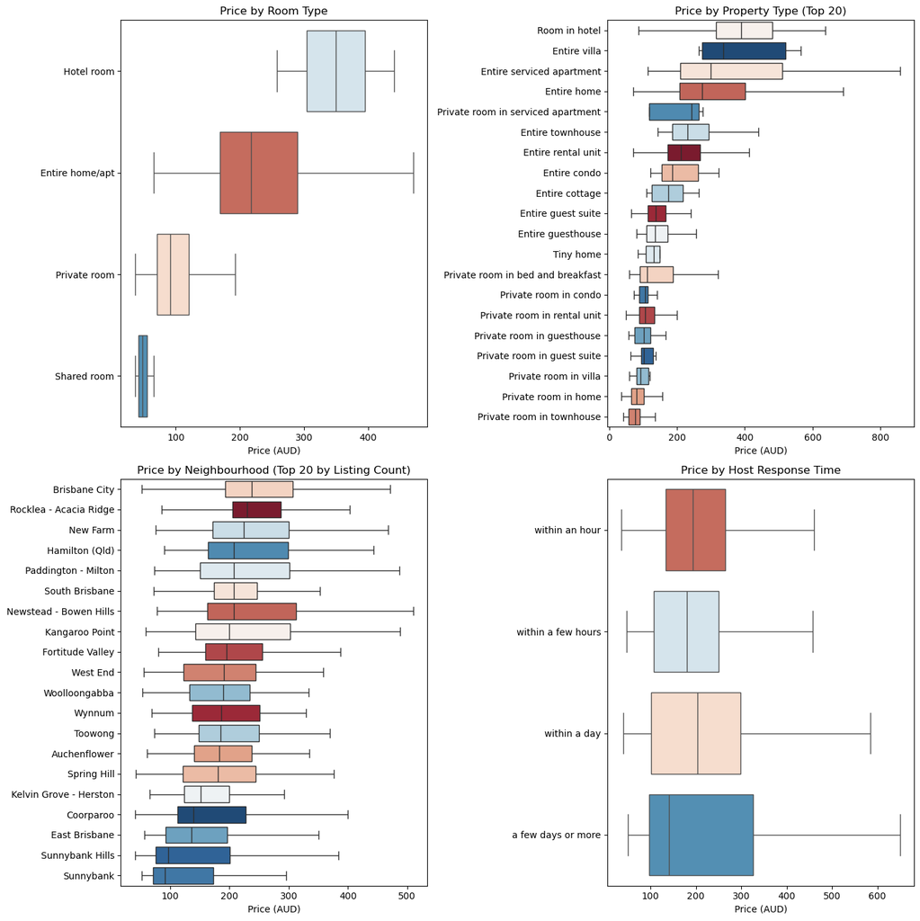

```python
fig, axes = plt.subplots(2, 2, figsize=(14, 14))

# Room type
order_rt = train_data.groupby('room_type')['price_clean'].median().sort_values(ascending=False).index
sns.boxplot(data=train_data, x='price_clean', y='room_type', order=order_rt,
            hue='room_type', palette='RdBu', legend=False,
            showfliers=False, ax=axes[0, 0])
axes[0, 0].set_title('Price by Room Type')
axes[0, 0].set_xlabel('Price (AUD)')
axes[0, 0].set_ylabel('')

# Property type
top20_prop = train_data['property_type'].value_counts().nlargest(20).index
prop_data  = train_data[train_data['property_type'].isin(top20_prop)]
order_prop = prop_data.groupby('property_type')['price_clean'].median().sort_values(ascending=False).index
sns.boxplot(data=prop_data, x='price_clean', y='property_type', order=order_prop,
            hue='property_type', palette='RdBu', legend=False,
            showfliers=False, ax=axes[0, 1])
axes[0, 1].set_title('Price by Property Type (Top 20)')
axes[0, 1].set_xlabel('Price (AUD)')
axes[0, 1].set_ylabel('')

# Neighbourhood
top20_neigh = train_data['neighbourhood_cleansed'].value_counts().nlargest(20).index
neigh_data  = train_data[train_data['neighbourhood_cleansed'].isin(top20_neigh)]
order_neigh = neigh_data.groupby('neighbourhood_cleansed')['price_clean'].median().sort_values(ascending=False).index
sns.boxplot(data=neigh_data, x='price_clean', y='neighbourhood_cleansed', order=order_neigh,
            hue='neighbourhood_cleansed', palette='RdBu', legend=False,
            showfliers=False, ax=axes[1, 0])
axes[1, 0].set_title('Price by Neighbourhood (Top 20 by Listing Count)')
axes[1, 0].set_xlabel('Price (AUD)')
axes[1, 0].set_ylabel('')

# Host response time
rt_order = ['within an hour', 'within a few hours', 'within a day', 'a few days or more']
rt_data  = train_data.dropna(subset=['host_response_time'])
sns.boxplot(data=rt_data, x='price_clean', y='host_response_time', order=rt_order,
            hue='host_response_time', palette='RdBu', legend=False,
            showfliers=False, ax=axes[1, 1])
axes[1, 1].set_title('Price by Host Response Time')
axes[1, 1].set_xlabel('Price (AUD)')
axes[1, 1].set_ylabel('')

plt.tight_layout()
plt.show()
```

- *Room type*:

Clear price ranking by privacy/exclusivity: Hotel rooms highest (~$350 median), then Entire home/apt (~$220), Private rooms (~$100), and Shared rooms (~$60). Hotel and entire-home listings show wider spread and long upper tails (standard + premium offerings); private/shared rooms are more concentrated. Retained as a key categorical feature.

- *Property type*

- *Neighbourhood*

Location matters: inner-city areas (Brisbane City, New Farm, Hamilton, Paddington-Milton) have higher medians; outer suburbs (Sunnybank, Sunnybank Hills, East Brisbane) lower. Inner-city areas show wider spread (mix of standard and premium); cheaper suburbs are more homogeneous. Reflects proximity to CBD, transport, and attractions — `neighbourhood_cleansed` retained.

- *Host response time*

Medians and IQRs are broadly similar across all categories, so response time alone is a weak price predictor. Retained anyway, as it may add value in combination with other host/listing features.

- *Amenities*

Not visualised (raw list-format text). Will be feature-engineered in Task 2 into `amenities_count` as a proxy for listing quality, expected to relate positively to price.

**3. Boolean Feature Analysis**

> Three boolean features were examined using box plots to assess their relationship with price.

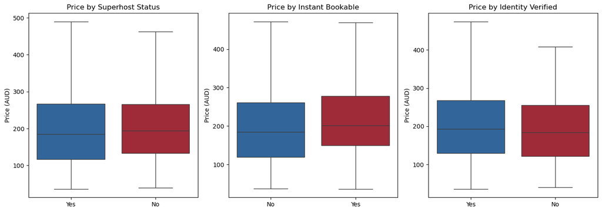

```python
fig, axes = plt.subplots(1, 3, figsize=(14, 5))

for ax, col, title in zip(
    axes, bool_features, ['Superhost Status', 'Instant Bookable', 'Identity Verified']
):
    plot_data = train_data.dropna(subset=[col]).copy()
    plot_data[col] = plot_data[col].map({'t': 'Yes', 'f': 'No'})
    sns.boxplot(data=plot_data, x=col, y='price_clean', showfliers=False,
                hue=col, palette=['#2166AC', '#B2182B'], legend=False, ax=ax)
    ax.set_title(f'Price by {title}')
    ax.set_xlabel('')
    ax.set_ylabel('Price (AUD)')

plt.tight_layout()
plt.show()
```

- *Superhost Status*

Median price barely differs between Superhost and non-Superhost listings, with almost fully overlapping IQRs. Weak direct relationship, but `host_is_superhost` is retained as a proxy for host experience, reliability, and service quality.

- *Instant Bookable*

Small median-price difference with substantial overlap, so `instant_bookable` is only weakly associated with price. Retained because it captures booking flexibility and host preferences that may shape booking behaviour.

- *Identity Verified*

All three boolean features show weak individual links to price, but each reflects a different aspect of host quality, credibility, or booking behaviour not captured by physical property traits — so all three were retained for modelling.

Overall, the three boolean features exhibit relatively weak individual relationships with price. However, they capture different aspects of host quality, credibility, and booking behaviour that are not reflected by physical property characteristics alone. For this reason, all three features were retained for subsequent modelling despite their limited standalone predictive strength.

**d. The remaining variables**

```python
train_data['host_response_rate_num'] = (
    train_data['host_response_rate']
    .str.replace('%', '')
    .astype(float)
)

train_data['host_acceptance_rate_num'] = (
    train_data['host_acceptance_rate']
    .str.replace('%', '')
    .astype(float)
)

cols = [
    'host_response_rate_num',
    'host_acceptance_rate_num',
    'host_listings_count',
    'review_scores_rating',
    'review_scores_accuracy',
    'review_scores_checkin',
    'review_scores_value',
    'review_scores_communication',
    'minimum_nights',
    'number_of_reviews'
]

for col in cols:
    print(col, train_data['price_clean'].corr(train_data[col]))
```

```
host_response_rate_num -0.08288466135244607
host_acceptance_rate_num -0.09046667465899677
host_listings_count 0.08193769983530433
review_scores_rating 0.04975361544327901
review_scores_accuracy 0.03240047010212609
review_scores_checkin -0.003072699111980201
review_scores_value -0.008516669152640401
review_scores_communication 0.012249263464392677
minimum_nights 0.0058881344136950675
number_of_reviews -0.08195712837093448
```

- *Host behaviour metrics*

`host_response_rate`, `host_acceptance_rate`, and `host_listings_count` all correlate weakly with price (|corr| < 0.1). Host behaviour alone doesn't determine price, but they capture host reliability, experience, and business activity and may add value alongside other features — so retained.

- *Review scores*

`review_scores_rating`, `accuracy`, `checkin`, `value`, and `communication` show only weak linear ties to price. guest satisfaction may affect pricing non-linearly (not captured by Pearson), and each reflects a different quality/experience dimension — so retained.

- *Minimum nights*

Very weak correlation (0.006) but retained on domain grounds, as it represents a key booking policy; selection balanced statistics with domain relevance.

- *Review counts*

Weak correlation, but the three capture different demand signals: `number_of_reviews` (long-term popularity) vs `number_of_reviews_ltm` / `number_of_reviews_l30d` (recent activity). All three kept to cover both historical and recent demand.

- **Retained for feature engineering**

`host_since`, `last_review`, `latitude`, `longitude`, `amenities`, and `name` show weak direct links to price in raw form but hold information that can be transformed into stronger predictors in Tasks 2–3, so they were kept for further processing.

## Task 2: Data Cleaning, Missing Observations and Feature Engineering

#### 1. Numerical Data Cleaning

```python
train_data['price'] = (train_data['price'].str.replace('$', '', regex=False)
                               .str.replace(',', '', regex=False)
                               .astype(float))

# Remove non-numeric characters and cast to float — applied to BOTH train and test
for df in [train_data, test_data]:
    df['host_response_rate']  = (df['host_response_rate'].str.replace('%', '', regex=False)
                                                          .astype(float))
    df['host_acceptance_rate'] = (df['host_acceptance_rate'].str.replace('%', '', regex=False)
                                                             .astype(float))

print("train_data dtypes:")
print(train_data[['price','host_response_rate','host_acceptance_rate']].dtypes)
```

```
train_data dtypes:
price                   float64
host_response_rate      float64
host_acceptance_rate    float64
dtype: object
```

```python
train_data.host_response_rate
```

```
0       100.0
1       100.0
2       100.0
3       100.0
4       100.0
        ...
3730    100.0
3731    100.0
3732     99.0
3733    100.0
3734    100.0
Name: host_response_rate, Length: 3735, dtype: float64
```

```python
# Verify all numerical features are numeric types
dtype_report = train_data[num_features].dtypes.to_frame('dtype')
display(dtype_report)
print(f"\nAll {len(num_features)} features confirmed numeric: "
      f"{train_data[num_features].select_dtypes(include='number').shape[1] == len(num_features)}")
```

|  | dtype |
| --- | --- |
| bathrooms | float64 |
| estimated_occupancy_l365d | int64 |
| review_scores_rating | float64 |
| review_scores_accuracy | float64 |
| review_scores_cleanliness | float64 |
| review_scores_checkin | float64 |
| review_scores_communication | float64 |
| review_scores_location | float64 |
| review_scores_value | float64 |
| reviews_per_month | float64 |
| calculated_host_listings_count | int64 |
| latitude | float64 |
| longitude | float64 |
| accommodates | int64 |
| bedrooms | float64 |
| beds | float64 |
| minimum_nights | int64 |
| maximum_nights | int64 |
| availability_30 | int64 |
| availability_365 | int64 |
| number_of_reviews | int64 |
| number_of_reviews_ltm | int64 |
| number_of_reviews_l30d | int64 |
| host_listings_count | float64 |

```
All 24 features confirmed numeric: True
```

**Steps of numerical data cleaning:**

- Looking at all the selected numeric features, I notice that there are three text-based features required conversion before modelling: `price`, `host_response_rate`, and `host_acceptance_rate`.
  - `price`: initially stored as a string with leading `$` and comma separators. Both characters were removed and the column was cast to `float64`.
  - `host_response_rate` and `host_acceptance_rate`: initially stored as percentage strings (e.g: `"97%"`). The `%` symbol was removed and values were cast to `float64`, yielding a numeric scale of 0–100.
- After that, I verify the transformations by printing the dtypes of the three cleaned columns to confirm they are now numeric (float64).
- Finally, I audit all numerical features by generating a dtype report for every column in num_features and programmatically confirming that all of them are numeric types, ensuring no string-encoded values remain before modeling.

All transformations were applied identically to both training and test datasets. The dtype verification confirms that all numerical features are now stored as numeric types, making them suitable for use in scikit-learn estimators.

#### 2. Feature Engineering

```python
from sklearn.cluster import KMeans
from sklearn.preprocessing import StandardScaler
from sklearn.decomposition import PCA
from sklearn.pipeline import Pipeline
from sklearn.impute import SimpleImputer

# Feature engineering
SNAPSHOT_DATE = pd.Timestamp('2025-12-01')  # after all known scrape dates
CBD_LAT, CBD_LON = -27.4698, 153.0251 #Brisbane CBD


def haversine_cbd(lat, lon):
    R = 6371
    lat1, lon1 = np.radians(lat), np.radians(lon)
    lat2, lon2 = np.radians(CBD_LAT), np.radians(CBD_LON)
    dlat, dlon = lat2 - lat1, lon2 - lon1
    a = np.sin(dlat/2)**2 + np.cos(lat1) * np.cos(lat2) * np.sin(dlon/2)**2
    return R * 2 * np.arcsin(np.sqrt(a))

def safe_ratio(numerator, denominator):
    """
    denominator == 0 ~ NaN (not 1). NaN will be impute later
    """
    denom = denominator.replace(0, np.nan)
    return numerator / denom

def new_features(df):
    # 1. amenities_count: number of amenities
    am = df['amenities'].fillna('[]')
    df['amenities_count'] = np.where(am == '[]', 0, am.str.count(',') + 1)

    # 2. host_experience_days: days since host joined Airbnb
    host_since = pd.to_datetime(df['host_since'], errors='coerce')
    df['host_experience_days'] = (SNAPSHOT_DATE - host_since).dt.days.clip(lower=0)

    # 3. days_since_last_review: days since last review
    last_review = pd.to_datetime(df['last_review'], errors='coerce')
    df['days_since_last_review'] = (SNAPSHOT_DATE - last_review).dt.days

    # 4. is_commercial_host: 1 if host manages more than 1 listing
    df['is_commercial_host'] = (df['host_listings_count'] > 1).astype(int)

    # 5. beds_per_person: bed-to-guest ratio — proxy for comfort level
    df['beds_per_person'] = safe_ratio(df['beds'], df['accommodates'])

    # 6. bathroom/bedroom: bathrooms per bedroom — proxy for luxury level
    df['bath_to_bedroom_ratio'] = safe_ratio(df['bathrooms'], df['bedrooms'])

    # 7. accommodates_per_bedroom: guest capacity per bedroom — space density proxy
    df['accommodates_per_bedroom'] = safe_ratio(df['accommodates'], df['bedrooms'])

    # 8. availability_rate: proportion of year the listing is available
    df['availability_rate'] = df['availability_365'] / 365

    # 9. dist_to_cbd: Haversine distance (km) from listing to Brisbane CBD
    df['dist_to_cbd'] = haversine_cbd(df['latitude'], df['longitude'])

    # 10. Capture the structural 'Zero' state explicitly
    df['is_inactive_host'] = (df['estimated_occupancy_l365d'] == 0).astype(int)
    return df

# apply consistently on both set (explicit reassignment for pandas CoW safety)
train_data = new_features(train_data)
test_data  = new_features(test_data)


# -----step 2: cluster FIT ONLY TRAIN, NOT TEST
# geo_cluster: K-Means spatial cluster (fit on train only to avoid leakage)
_geo_scaler = StandardScaler().fit(train_data[['latitude', 'longitude']])
_kmeans_geo = KMeans(n_clusters=5, random_state=42, n_init=10)
_kmeans_geo.fit(_geo_scaler.transform(train_data[['latitude', 'longitude']]))

for df in [train_data, test_data]:
    labels = _kmeans_geo.predict(_geo_scaler.transform(df[['latitude', 'longitude']]))
    df['geo_cluster'] = ['zone_' + str(l) for l in labels]


# --- Step 3: Drop unnecessary columns and keep only new feature and the rest
DROP_COLS = [
    'availability_365',          # same with availability_rate
    'latitude', 'longitude',     # dist_to_cbd + geo_cluster
    'host_since', 'last_review', 'first review'  # feature engine done
]
for df in [train_data, test_data]:
    df.drop(columns=[c for c in DROP_COLS if c in df.columns], inplace=True)

NEW_FEATURES = [
    'amenities_count', 'host_experience_days', 'days_since_last_review', 'is_commercial_host', 'beds_per_person',
    'bath_to_bedroom_ratio', 'accommodates_per_bedroom', 'availability_rate',
    'dist_to_cbd', 'geo_cluster',
]
```

### **Comments:**

Ten new features were constructed from the raw data to capture additional signal not directly available in the original columns. All transformations were applied consistently to both the training and test sets. Where a transformation requires fitting (e.g. K-Means clustering, StandardScaler), parameters were estimated on the training set only and then applied to the test set to prevent data leakage.

**1. `amenities_count`**

- **Construction:** Count the number of commas in the `amenities` JSON string and add 1; assign 0 for empty lists.
- **Justification:** Listings with more amenities offer greater comfort and convenience, which typically commands a higher price.

**2. `host_experience_days`**

- **Construction:** Number of days elapsed between `host_since` and the snapshot date (2025-12-01), clipped at 0.
- **Justification:** More experienced hosts understand the market better and tend to price their listings more competitively and accurately.

**3. `days_since_last_review`**

- **Construction:** Number of days elapsed between `last_review` and the snapshot date (2025-12-01).
- **Justification:** Recently reviewed listings signal active demand. Listings with no recent reviews may be underpriced or less popular, which affects price.

**4. `is_commercial_host`**

- **Construction:** Binary flag — 1 if `host_listings_count > 1`, else 0.
- **Justification:** Commercial hosts managing multiple listings tend to price more strategically and maintain higher quality standards, which may correlate with higher prices.

**5. `beds_per_person`**

- **Construction:** `beds / accommodates`. Zero denominator is replaced with NaN and imputed in the missing value step.
- **Justification:** A higher bed-to-guest ratio indicates greater comfort. Listings with more beds per person can justify higher prices.

**6. `bath_to_bedroom_ratio`**

- **Construction:** `bathrooms / bedrooms`. Zero denominator is replaced with NaN and imputed in the missing value step.
- **Justification:** More bathrooms relative to bedrooms is a proxy for luxury. Higher ratios are associated with premium listings.

**7. `accommodates_per_bedroom`**

- **Construction:** `accommodates / bedrooms`. Zero denominator is replaced with NaN and imputed in the missing value step.
- **Justification:** Measures space density — lower values indicate more spacious listings, which typically command higher prices per guest.

**8. `availability_rate`**

- **Construction:** `availability_365 / 365`, giving a proportion in [0, 1].
- **Justification:** Low availability may indicate high demand, which supports higher pricing. Highly available listings may be less sought-after and priced lower to attract bookings.

**9. `dist_to_cbd`**

- **Construction:** Haversine great-circle distance (km) from the listing's coordinates to Brisbane CBD (−27.4698°, 153.0251°).
- **Justification:** Proximity to the CBD is a key price driver in urban markets. Listings closer to the city centre typically command a premium due to convenience and accessibility.

**10. `geo_cluster`**

- **Construction:** K-Means clustering (k = 5) applied to StandardScaler- normalised latitude and longitude. The scaler and cluster centroids were fit on the training set only; the test set was transformed using the same parameters.
- **Justification:** Captures spatial price patterns beyond a single distance metric. Neighbourhoods within the same zone share similar price levels, providing richer location signal than `dist_to_cbd` alone.

##### Dropped Source Columns

After feature engineering, the following source columns were dropped as their information has been fully captured by the new features:

[output not shown]

### **Room for Improvement 1:**

```python
# --- Ammenities handle
AMENITY_MAP = {
    'has_wifi'             : r'wi-?fi',
    'has_heating'          : r'heating',
    'has_essentials'       : r'essentials',
    'has_kitchen'          : r'kitchen',
    'has_smoke_alarm'      : r'smoke alarm',
    'has_air_conditioning' : r'air conditioning',
    'has_hangers'          : r'hangers',
    'has_workspace'        : r'workspace',
    'has_coffee_maker'     : r'coffee maker',
    'has_hot_water_kettle' : r'hot water kettle',
    'has_hair_dryer'       : r'hair dryer',
    'has_iron'             : r'\biron\b',
    'has_tv'               : r'\btv\b|hdtv|television',
    'has_hot_water'        : r'hot water(?! kettle)',
    'has_washer'           : r'\bwasher\b',
    'has_dryer'            : r'(?<!hair )dryer',
    'has_first_aid_kit'    : r'first aid kit',
    'has_fire_extinguisher': r'fire extinguisher',
    'has_refrigerator'     : r'refrigerator',
    'has_pool'             : r'\bpool\b',
    'has_gym'              : r'gym|fitness|exercise equipment',
    'has_pets_allowed'     : r'pets allowed',
    'has_free_parking'     : r'free[^"]*parking',
    'has_paid_parking'     : r'paid[^"]*parking',
    'has_self_checkin'     : r'self check-?in',
}
# Selecting top n amentities based on train frequency
TOP_N = len(AMENITY_MAP)

# Binary setting for train and test based on Amentity_MAP
for df in [train_data, test_data]:
    amenities_str = df['amenities'].fillna('[]').str.lower()
    for col, pattern in AMENITY_MAP.items():
        df[col] = amenities_str.str.contains(pattern, regex=True).astype(int)

# ── Name keyword features ────────────────────────────────────────────────
NAME_KEYWORDS = {
    'name_luxury'   : r'luxury|luxurious',
    'name_pool'     : r'\bpool\b',
    'name_view'     : r'\bview\b|views',
    'name_studio'   : r'\bstudio\b',
    'name_cbd'      : r'\bcbd\b|city centre|city center',
    'name_beach'    : r'\bbeach\b|beachside|beachfront',
    'name_ocean'    : r'\bocean\b',
    'name_penthouse': r'\bpenthouse\b',
    'name_modern'   : r'\bmodern\b|contemporary',
}
for df in [train_data, test_data]:
    name_str = df['name'].fillna('').str.lower()
    for col, pattern in NAME_KEYWORDS.items():
        df[col] = name_str.str.contains(pattern, regex=True).astype(int)

NAME_FEATURES = list(NAME_KEYWORDS.keys())
print(f"Name keyword features: {NAME_FEATURES}")

# Calculate frequency of amenities map on train
all_cols = list(AMENITY_MAP.keys())
freq = train_data[all_cols].mean().sort_values(ascending=False)
print("Frequency amenity (train):")
print(freq.round(3).to_string())

kept = freq[freq >= 0.0].index[:TOP_N].tolist()
dropped = [c for c in all_cols if c not in kept]
print(f"\keep {len(kept)} cols | Drop: {dropped if dropped else 'None'}")

# add amenity features to list of selected feature
for df in [train_data, test_data]:
    df.drop(columns=[c for c in dropped if c in df.columns], inplace=True)

AMENITY_FEATURES = kept
```

```
Name keyword features: ['name_luxury', 'name_pool', 'name_view', 'name_studio', 'name_cbd', 'name_beach', 'name_ocean', 'name_penthouse', 'name_modern']
Frequency amenity (train):
has_wifi                 0.960
has_smoke_alarm          0.955
has_kitchen              0.953
has_washer               0.925
has_tv                   0.902
has_hot_water            0.804
has_hangers              0.792
has_refrigerator         0.787
has_air_conditioning     0.782
has_hair_dryer           0.776
has_iron                 0.773
has_free_parking         0.740
has_hot_water_kettle     0.721
has_essentials           0.674
has_self_checkin         0.652
has_heating              0.622
has_dryer                0.595
has_workspace            0.506
has_pool                 0.473
has_fire_extinguisher    0.434
has_first_aid_kit        0.379
has_coffee_maker         0.368
has_gym                  0.331
has_paid_parking         0.150
has_pets_allowed         0.118
\keep 25 cols | Drop: None
```

### Amenity & Listing Name Features

In addition to `amenities_count`, individual binary features were extracted from the `amenities` JSON string and the listing `name` field to capture the presence of specific attributes that may influence price.

**Amenity Binary Features (`has_*`)**

- Given some research, one particular column of interest was ‘amenities’, a text variable with over 2000 unique values. To handle this, we performed examination, cleaning, aggregation and split the column into individual binary variables. Each binary variable represented whether a particular amenity was included in the listing, with 1 indicating its presence and 0 indicating otherwise.
- The identification of the top 25 amenities was carried out by leveraging insights from various research studies that focused on investigating their impact, including a list given below:

WiFi, heating, essentials, kitchen, smoke alarm, air conditioning, hangers, workspace, coffee maker, hot water kettle, hair dryer, iron, TV, hot water, washer, dryer, first aid kit, fire extinguisher, refrigerator, pool, gym, pets allowed, free parking, paid parking, self check-in

**Listing Name Keyword Features (`name_*`)**

- **Construction:** For each keyword in `NAME_KEYWORDS`, a binary flag (1/0) is created by applying a regular expression to the lowercased `name` field.
- **Features extracted (9 total):** `name_luxury`, `name_pool`, `name_view`, `name_studio`, `name_cbd`, `name_beach`, `name_ocean`, `name_penthouse`, `name_modern`.
- **Justification:** Hosts deliberately use premium keywords in listing titles to signal quality and attract higher-paying guests. Listings mentioning "luxury", "penthouse", or "ocean" are likely priced higher than comparable listings without such descriptors, making these keywords useful price signals.

**Frequency Filtering**

Amenity frequency was calculated on the training set only to avoid data leakage. All 25 amenities in `AMENITY_MAP` were retained as their frequency threshold was set to ≥ 0 — meaning no amenity was dropped at this stage. This ensures the full set of hand-curated amenity signals is preserved for model training.

#### 3. Missing Values

```python
# Assemble train_data_selection / test_data_selection
REVIEW_SCORE_FEATURES = [
    'review_scores_rating', 'review_scores_cleanliness',
    'review_scores_location', 'review_scores_accuracy',
    'review_scores_communication', 'review_scores_checkin',
    'review_scores_value'
]

BASE_NUM_FEATURES = [
    'host_response_rate', 'host_acceptance_rate',
    'host_listings_count',
    'estimated_occupancy_l365d',
    'accommodates', 'bathrooms', 'bedrooms', 'beds',
    'minimum_nights', 'maximum_nights',
    'availability_30',
    'number_of_reviews', 'number_of_reviews_ltm', 'number_of_reviews_l30d',
    'reviews_per_month',
    *REVIEW_SCORE_FEATURES,
]

ENG_NUM_FEATURES = [
    'amenities_count', 'host_experience_days', 'days_since_last_review',
    'is_commercial_host', 'beds_per_person', 'bath_to_bedroom_ratio',
    'accommodates_per_bedroom', 'availability_rate', 'dist_to_cbd',
]

CAT_FEATURES  = ['room_type', 'property_type', 'neighbourhood_cleansed',
                 'host_response_time', 'geo_cluster']

BOOL_FEATURES = ['host_is_superhost', 'instant_bookable', 'host_identity_verified']

ALL_FEATURES = (BASE_NUM_FEATURES + ENG_NUM_FEATURES + CAT_FEATURES
                + BOOL_FEATURES + AMENITY_FEATURES + NAME_FEATURES)

train_cols = [c for c in ALL_FEATURES if c in train_data.columns]
test_cols  = [c for c in ALL_FEATURES if c in test_data.columns]

train_data_selection = train_data[train_cols + ['price']].copy()
test_data_selection  = test_data[test_cols].copy()

print(f"train_data_selection: {train_data_selection.shape}")
print(f"test_data_selection : {test_data_selection.shape}")
```

```
train_data_selection: (3735, 74)
test_data_selection : (1601, 73)
```

```python
train_data_selection.columns
```

```
Index(['host_response_rate', 'host_acceptance_rate', 'host_listings_count',
       'estimated_occupancy_l365d', 'accommodates', 'bathrooms', 'bedrooms',
       'beds', 'minimum_nights', 'maximum_nights', 'availability_30',
       'number_of_reviews', 'number_of_reviews_ltm', 'number_of_reviews_l30d',
       'reviews_per_month', 'review_scores_rating',
       'review_scores_cleanliness', 'review_scores_location',
       'review_scores_accuracy', 'review_scores_communication',
       'review_scores_checkin', 'review_scores_value', 'amenities_count',
       'host_experience_days', 'days_since_last_review', 'is_commercial_host',
       'beds_per_person', 'bath_to_bedroom_ratio', 'accommodates_per_bedroom',
       'availability_rate', 'dist_to_cbd', 'room_type', 'property_type',
       'neighbourhood_cleansed', 'host_response_time', 'geo_cluster',
       'host_is_superhost', 'instant_bookable', 'host_identity_verified',
       'has_wifi', 'has_smoke_alarm', 'has_kitchen', 'has_washer', 'has_tv',
       'has_hot_water', 'has_hangers', 'has_refrigerator',
       'has_air_conditioning', 'has_hair_dryer', 'has_iron',
       'has_free_parking', 'has_hot_water_kettle', 'has_essentials',
       'has_self_checkin', 'has_heating', 'has_dryer', 'has_workspace',
       'has_pool', 'has_fire_extinguisher', 'has_first_aid_kit',
       'has_coffee_maker', 'has_gym', 'has_paid_parking', 'has_pets_allowed',
       'name_luxury', 'name_pool', 'name_view', 'name_studio', 'name_cbd',
       'name_beach', 'name_ocean', 'name_penthouse', 'name_modern', 'price'],
      dtype='object')
```

**Check variables with missing value:**

**Check distribution of missing value of numeric features**

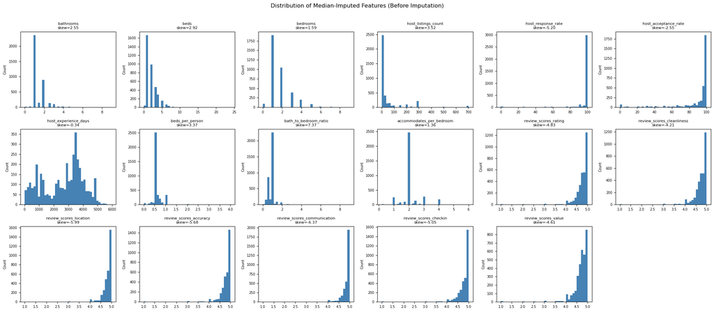

```python
import math

median_plot_cols = [
    'bathrooms', 'beds', 'bedrooms', 'host_listings_count',
    'host_response_rate', 'host_acceptance_rate', 'host_experience_days',
    'beds_per_person', 'bath_to_bedroom_ratio', 'accommodates_per_bedroom',
    'review_scores_rating', 'review_scores_cleanliness', 'review_scores_location',
    'review_scores_accuracy', 'review_scores_communication',
    'review_scores_checkin', 'review_scores_value',
]

ncols = 6
nrows = math.ceil(len(median_plot_cols) / ncols)

fig, axes = plt.subplots(nrows, ncols, figsize=(ncols * 3.5, nrows * 3))
axes = axes.flatten()

for ax, col in zip(axes, median_plot_cols):
    data = train_data_selection[col].dropna()
    ax.hist(data, bins=40, color='steelblue', edgecolor='none')
    ax.set_title(f'{col}\nskew={data.skew():.2f}', fontsize=8)
    ax.set_xlabel('')
    ax.set_ylabel('Count', fontsize=7)
    ax.tick_params(labelsize=7)
for ax in axes[len(median_plot_cols):]:
    ax.set_visible(False)

plt.suptitle('Distribution of Median-Imputed Features (Before Imputation)', fontsize=12, y=1.01)
plt.tight_layout()
plt.show()
```

```python
# Compute imputation values from TRAIN only (avoid data leakage)
REVIEW_SCORE_FEATURES = [
    'review_scores_rating', 'review_scores_cleanliness',
    'review_scores_location', 'review_scores_accuracy',
    'review_scores_communication', 'review_scores_checkin',
    'review_scores_value'
]

median_num_cols = [
    'bathrooms', 'beds', 'bedrooms', 'host_listings_count',
    'host_response_rate', 'host_acceptance_rate',
    'host_experience_days', 'beds_per_person', 'bath_to_bedroom_ratio',
    'accommodates_per_bedroom',
    *REVIEW_SCORE_FEATURES,
]
medians = train_data_selection[median_num_cols].median()
max_day_no_review = train_data_selection['days_since_last_review'].max()

for df in [train_data_selection, test_data_selection]:
    df['days_since_last_review'] = df['days_since_last_review'].fillna(max_day_no_review)
    df['reviews_per_month']      = df['reviews_per_month'].fillna(0)
    for col in median_num_cols:
        df[col] = df[col].fillna(medians[col])
    df['host_response_time']     = df['host_response_time'].fillna('unknown')
    df['host_is_superhost']      = df['host_is_superhost'].fillna('f')
    df['host_identity_verified'] = df['host_identity_verified'].fillna('f')

nan_check = train_data_selection[median_num_cols].isna().sum().sum()
print(f"NaN remaining after imputation: {nan_check}")
```

```
NaN remaining after imputation: 0
```

### Missing Value Imputation

Missing values were handled differently depending on the nature of each feature. All imputation parameters were computed on the training set only and then applied to the test set to avoid data leakage.

**1. Median Imputation — Continuous Numerical Features**

Features: `bathrooms`, `beds`, `bedrooms`, `host_listings_count`, `host_response_rate`, `host_acceptance_rate`, `host_experience_days`, `beds_per_person`, `bath_to_bedroom_ratio`, `accommodates_per_bedroom`, and all `review_scores_*` features.

The median of each feature was computed from the training set and used to fill missing values in both train and test. Median was chosen over mean because several of these features are right-skewed with outliers — the median is more robust and better represents the typical listing.

**2. Zero Imputation —** `reviews_per_month`

Missing values in `reviews_per_month` indicate listings that have never been reviewed. Filling with 0 is semantically correct — these listings have zero reviews per month rather than an unknown value.

**3. Maximum Value Imputation —** `days_since_last_review`

Listings with no review have a missing `last_review` date, meaning `days_since_last_review` cannot be computed. These are imputed with the maximum observed value in the training set, representing the longest time since any listing was last reviewed. This correctly signals that these listings are the least recently reviewed — more extreme than any observed value would be inappropriate as it could extrapolate beyond the data.

**4. Constant Imputation — Categorical & Binary Features**

- `host_response_time` → filled with `'unknown'`: missing response time suggests the host has not set a response policy, which is meaningfully different from any of the four response time categories.
- `host_is_superhost` → filled with `'f'` (False): a missing superhost status is most likely a non-superhost host, as the badge is explicitly awarded and displayed.
- `host_identity_verified` → filled with `'f'` (False): same reasoning — verified status is explicitly granted and displayed; missing implies not verified.

#### 4. Encoding Categorical Variables

##### Comments:

All the categorical features that has been selected are: `room_type`, `property_type`, `neighbourhood_cleansed`, `host_response_time`, `geo_cluster`

```python
train_data_selection[CAT_FEATURES]
```

|  | room_type | property_type | neighbourhood_cleansed | host_response_time | geo_cluster |
| --- | --- | --- | --- | --- | --- |
| 0 | Entire home/apt | Entire rental unit | Rocklea - Acacia Ridge | within an hour | zone_1 |
| 1 | Entire home/apt | Entire guest suite | Wynnum | within an hour | zone_2 |
| 2 | Entire home/apt | Entire rental unit | Fortitude Valley | within an hour | zone_4 |
| 3 | Entire home/apt | Entire rental unit | Newstead - Bowen Hills | within an hour | zone_4 |
| 4 | Entire home/apt | Entire rental unit | Fortitude Valley | within an hour | zone_4 |
| ... | ... | ... | ... | ... | ... |
| 3730 | Private room | Private room in home | Holland Park | within an hour | zone_1 |
| 3731 | Private room | Private room in bungalow | Robertson | within an hour | zone_1 |
| 3732 | Entire home/apt | Entire rental unit | South Brisbane | within an hour | zone_4 |
| 3733 | Entire home/apt | Entire rental unit | Kelvin Grove - Herston | within a few hours | zone_4 |
| 3734 | Private room | Private room in condo | Brisbane City | within an hour | zone_4 |

3735 rows × 5 columns

**a. High-Cardinality Nominal Features — Collapsing + One-Hot Encoding**

- **One-hot encoding** was then applied via `pd.get_dummies`. The test set was

realigned to match the training set's dummy columns using `reindex`, filling any unseen categories with 0. This ensures the feature matrix passed to the model has identical columns across train and test.

- One-hot encoding was chosen because these features have no natural ordering —

for example, there is no inherent ranking between `room_type` categories such as "Entire home/apt" and "Private room". Assigning arbitrary integer labels would incorrectly imply an order that does not exist. - 1: indicates that the listing belongs to that room type/property type/neighbourhood/geo cluster, - 0: indicates that it does not.

```python
# ── Step 1: Collapse high-cardinality nominal features
# For features with >5 unique values, keep top 5 by frequency; rest → 'other'
CAT_NOMINAL  = ['room_type', 'property_type', 'neighbourhood_cleansed', 'geo_cluster']

TOP_N = 5
for col in CAT_NOMINAL:
    # Derive top categories from TRAIN only (avoid data leakage)
    top_cats = train_data_selection[col].value_counts().nlargest(TOP_N).index
    for df in [train_data_selection, test_data_selection]:
        df[col] = df[col].where(df[col].isin(top_cats), other='other')

print("Unique categories after collapsing (train):")
for col in CAT_NOMINAL:
    counts = train_data_selection[col].value_counts()
    print(f"\n  {col}:")
    print(counts.to_string())
```

```
Unique categories after collapsing (train):

  room_type:
room_type
Entire home/apt    2854
Private room        875
Shared room           4
Hotel room            2

  property_type:
property_type
Entire rental unit             1804
Entire home                     596
Private room in home            513
other                           504
Private room in rental unit     196
Entire guest suite              122

  neighbourhood_cleansed:
neighbourhood_cleansed
other                     2298
Brisbane City              567
South Brisbane             314
Fortitude Valley           277
Newstead - Bowen Hills     149
Spring Hill                130

  geo_cluster:
geo_cluster
zone_4    2798
zone_1     528
zone_0     232
zone_2     151
zone_3      26
```

```python
# # Step 2: One-hot encoding for nominal features
# Fit on TRAIN categories only; reindex TEST to match (fills unseen cols with 0)
cat_nominal = ['room_type', 'property_type', 'neighbourhood_cleansed', 'geo_cluster']

cat_dummies_train = pd.get_dummies(train_data_selection[cat_nominal],dtype= int)
cat_dummies_test  = pd.get_dummies(test_data_selection[cat_nominal],  dtype= int)
# Align test columns to match train (handles unseen data == 0)
cat_dummies_test  = cat_dummies_test.reindex(columns=cat_dummies_train.columns, fill_value=0)
```

[output not shown]

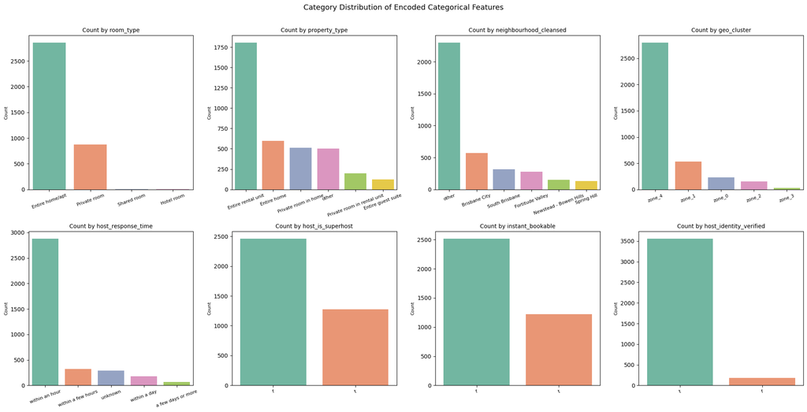

```python
# Categorical variables to check after encoding
cat_check = {
    'room_type'               : 'room_type',
    'property_type'           : 'property_type',
    'neighbourhood_cleansed'  : 'neighbourhood_cleansed',
    'geo_cluster'             : 'geo_cluster',
    'host_response_time'      : 'host_response_time',
    'host_is_superhost'       : 'host_is_superhost',
    'instant_bookable'        : 'instant_bookable',
    'host_identity_verified'  : 'host_identity_verified',
}

fig, axes = plt.subplots(2, 4, figsize=(20, 10))
axes = axes.flatten()

for ax, (title, col) in zip(axes, cat_check.items()):
    order = (train_data_selection[col]
             .value_counts()
             .sort_values(ascending=False)
             .index)
    sns.countplot(data=train_data_selection, x=col,
                  order=order, palette='Set2', ax=ax)
    ax.set_title(f'Count by {title}', fontsize=10)
    ax.set_xlabel('')
    ax.set_ylabel('Count', fontsize=8)
    ax.tick_params(axis='x', rotation=20, labelsize=8)

plt.suptitle('Category Distribution of Encoded Categorical Features', fontsize=13, y=1.01)
plt.tight_layout()
plt.show()
```

**b. Ordinal Feature — Ordinal Encoding**

Feature: `host_response_time`

This feature has a clear natural ordering from fastest to slowest response. It was encoded as integers 0–4 preserving this ranking:

| Category | Encoded Value |
| --- | --- |
| within an hour | 0 |
| within a few hours | 1 |
| within a day | 2 |
| a few days or more | 3 |
| unknown | 4 |

Note that `unknown` (imputed from missing values in the previous step) was assigned the highest value, representing the worst-case response behaviour — a host with no recorded response time is treated as the least responsive.

```python
# Step 3: Ordinal encoding for host_response_time
# Clear speed order: faster response → lower integer value; 'unknown' → highest reponse time
response_order = {
    'within an hour'    : 0,
    'within a few hours': 1,
    'within a day'      : 2,
    'a few days or more': 3,
    'unknown'           : 4,
}
for df in [train_data_selection, test_data_selection]:
    df['host_response_time'] = df['host_response_time'].map(response_order)
```

**c. Binary Features — Boolean Mapping (t/f → 1/0)**

Features: `host_is_superhost`, `instant_bookable`, `host_identity_verified`

These features take only two values (`t`/`f`). They were mapped directly to 1 and 0. This is equivalent to one-hot encoding with a single column and avoids creating a redundant second dummy column.

```python
# # Step 4: Convert boolean 't'/'f' → 1/0
bool_cols = ['host_is_superhost', 'instant_bookable', 'host_identity_verified']
for df in [train_data_selection, test_data_selection]:
    for col in bool_cols:
        df[col] = df[col].map({'t': 1, 'f': 0})
```

### Summary:

| Feature | Type | Categories after collapsing | Method | Reason |
| --- | --- | --- | --- | --- |
| `room_type` | Nominal | 4 (all retained, ≤ 5) | One-hot | No natural order; all 4 categories kept as-is |
| `property_type` | Nominal | 6 (top 5 + *other*) | One-hot | No natural order; low-frequency types collapsed into *other* to reduce noise |
| `neighbourhood_cleansed` | Nominal | 6 (top 5 + *other*) | One-hot | Same rationale as `property_type` |
| `host_response_time` | Ordinal | 5 | Label (0–4) | Clear speed ordering: *within an hour* (0) → *within a few hours* (1) → *within a day* (2) → *a few days or more* (3) → *unknown* (4) |
| `host_is_superhost` | Boolean | 2 | Binary (0/1) | Already binary; integer mapping is sufficient |
| `instant_bookable` | Boolean | 2 | Binary (0/1) | Same as above |
| `host_identity_verified` | Boolean | 2 | Binary (0/1) | Same as above |

#### **Room for Improvement 2**:

```python
# # Define final numeric feature list (used in Section 5)
exclude = cat_nominal + ['price']
all_features = [c for c in train_data_selection.columns if c not in exclude]
all_features
```

```
['host_response_rate',
 'host_acceptance_rate',
 'host_listings_count',
 'estimated_occupancy_l365d',
 'accommodates',
 'bathrooms',
 'bedrooms',
 'beds',
 'minimum_nights',
 'maximum_nights',
 'availability_30',
 'number_of_reviews',
 'number_of_reviews_ltm',
 'number_of_reviews_l30d',
 'reviews_per_month',
 'review_scores_rating',
 'review_scores_cleanliness',
 'review_scores_location',
 'review_scores_accuracy',
 'review_scores_communication',
 'review_scores_checkin',
 'review_scores_value',
 'amenities_count',
 'host_experience_days',
 'days_since_last_review',
 'is_commercial_host',
 'beds_per_person',
 'bath_to_bedroom_ratio',
 'accommodates_per_bedroom',
 'availability_rate',
 'dist_to_cbd',
 'host_response_time',
 'host_is_superhost',
 'instant_bookable',
 'host_identity_verified',
 'has_wifi',
 'has_smoke_alarm',
 'has_kitchen',
 'has_washer',
 'has_tv',
```

[output cut: 14 more lines]

```
 'has_fire_extinguisher',
 'has_first_aid_kit',
 'has_coffee_maker',
 'has_gym',
 'has_paid_parking',
 'has_pets_allowed',
 'name_luxury',
 'name_pool',
 'name_view',
 'name_studio',
 'name_cbd',
 'name_beach',
 'name_ocean',
 'name_penthouse',
 'name_modern']
```

```python
from sklearn.model_selection import KFold

# 5-fold target encoding for neighbourhood_cleansed
# Fit on train folds only (no leakage); test uses full-train mean per suburb
y_te        = np.log1p(train_data_selection['price'])
nc_train    = train_data['neighbourhood_cleansed']   # full 132 suburbs (pre-collapse)
nc_test     = test_data['neighbourhood_cleansed']
global_mean = y_te.mean()

kf = KFold(5, shuffle=True, random_state=42)
nc_te_train = np.zeros(len(train_data_selection))
for tr_idx, val_idx in kf.split(train_data_selection):
    fold_mean = y_te.iloc[tr_idx].groupby(nc_train.iloc[tr_idx]).mean()
    nc_te_train[val_idx] = nc_train.iloc[val_idx].map(fold_mean).fillna(global_mean).values

full_mean = y_te.groupby(nc_train).mean()
nc_te_test = nc_test.map(full_mean).fillna(global_mean).values

train_data_selection['neighbourhood_te'] = nc_te_train
test_data_selection['neighbourhood_te']  = nc_te_test

# Append to all_features so X_train/X_test include it
all_features.append('neighbourhood_te')

corr = np.corrcoef(nc_te_train, y_te)[0,1]
print(f"neighbourhood_te added — corr with log_price: {corr:.3f}  (top-5 OHE was ~0.215)")
```

```
neighbourhood_te added — corr with log_price: 0.369  (top-5 OHE was ~0.215)
```

#### 5. Additional Data Preparation (2 marks)

Perform any additional data preparation steps required before building predictive models.

- Consider steps such as scaling, transformations, or handling outliers
- Ensure that any transformations are applied consistently to both the training and test datasets
- Clearly describe each step you perform
- Briefly justify why these steps are necessary

### Check for skewness (count numeric variable and price)

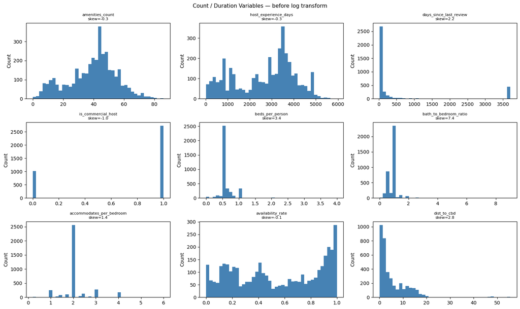

```python
ENG_NUM_FEATURES = [
    'amenities_count', 'host_experience_days', 'days_since_last_review',
    'is_commercial_host', 'beds_per_person', 'bath_to_bedroom_ratio',
    'accommodates_per_bedroom', 'availability_rate', 'dist_to_cbd'
]
fig, axes = plt.subplots(3, 3, figsize=(15,9))
for ax, col in zip(axes.flatten(), ENG_NUM_FEATURES):
    ax.hist(train_data_selection[col].dropna(), bins=40,
            color='steelblue', edgecolor='none')
    ax.set_title(f'{col}\nskew={train_data_selection[col].skew():.1f}', fontsize=8)
    ax.set_ylabel('Count')
plt.suptitle('Count / Duration Variables — before log transform', fontsize=11)
plt.tight_layout()
plt.show()
```

```python
skew_before = train_data_selection[BASE_NUM_FEATURES].skew().round(2)
skew_before
```

```
host_response_rate             -5.43
host_acceptance_rate           -2.65
host_listings_count             3.52
estimated_occupancy_l365d       0.70
accommodates                    1.60
bathrooms                       2.55
bedrooms                        1.59
beds                            2.93
minimum_nights                 18.42
maximum_nights                  1.01
availability_30                 0.35
number_of_reviews               4.01
number_of_reviews_ltm           2.27
number_of_reviews_l30d          2.07
reviews_per_month               1.71
review_scores_rating           -5.17
review_scores_cleanliness      -4.52
review_scores_location         -6.39
review_scores_accuracy         -6.07
review_scores_communication    -6.78
review_scores_checkin          -5.40
review_scores_value            -4.94
dtype: float64
```

**Skewness and Scaling Decision:**

### Log-transform the Target Variable and Assemble X and y for Models training

```python
# Log-transform the target variable (price)
print(f"Price skewness — original : {train_data_selection['price'].skew():.2f}")
y_train = np.log1p(train_data_selection['price'])
print(f"Price skewness — log1p    : {y_train.skew():.2f}")

# Assemble feature matrices
X_train = pd.concat([
    train_data_selection[all_features].reset_index(drop=True),
    cat_dummies_train.reset_index(drop=True),
], axis=1)

X_test = pd.concat([
    test_data_selection.reindex(columns=all_features, fill_value=0).reset_index(drop=True),
    cat_dummies_test.reset_index(drop=True),
], axis=1)

# Safety net: replace any residual inf with NaN, then fill with column median
for df in [X_train, X_test]:
    df.replace([np.inf, -np.inf], np.nan, inplace=True)

col_medians = X_train.median()
X_train.fillna(col_medians, inplace=True)
X_test.fillna(col_medians, inplace=True)

assert list(X_train.columns) == list(X_test.columns), "Column mismatch"
inf_remaining = np.isinf(X_train.values).sum()
nan_remaining = X_train.isna().sum().sum()
print(f"X_train: {X_train.shape},  X_test: {X_test.shape}")
print(f"inf in X_train: {inf_remaining}  |  NaN in X_train: {nan_remaining}")
```

```
Price skewness — original : 7.48
Price skewness — log1p    : 0.25
X_train: (3735, 91),  X_test: (1601, 91)
inf in X_train: 0  |  NaN in X_train: 0
```

**Check distribution of `price` after transformation:**

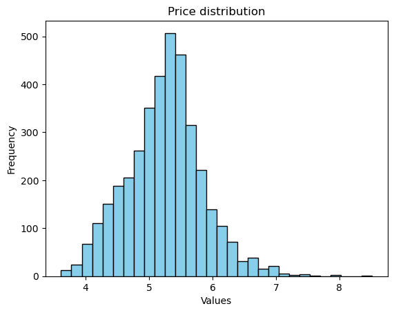

```python
# Create the histogram
plt.hist(y_train, bins=30, color='skyblue', edgecolor='black')

# Add titles and labels
plt.title('Price distribution')
plt.xlabel('Values')
plt.ylabel('Frequency')

# Display the plot
plt.show()
```

**Log-transformation of the target variable (`price`):**

After applying `log1p`, the transformed price distribution is approximately symmetric with a skewness of 0.251 — a substantial improvement from the original raw skewness of ~7–8.

The **mean** (5.246) and **median** (5.268) are nearly identical, differing by only 0.022, confirming that the log transformation has effectively compressed the central distribution.

The **standard deviation** of 0.603 in log space indicates moderate spread around the centre.

However, the histogram reveals that a small number of **outliers** remain — a right tail extending beyond 7 and a few low-value observations near 3–4 represent unusually cheap listings. These extreme values are not removed, as they reflect genuine market observations rather than data errors. Tree-based models such as Random Forest and Gradient Boosting are robust to such outliers since they partition the feature space by threshold splits rather than being influenced by the magnitude of individual values.

Predictions are back-transformed using `np.expm1()` before submission.

## Task 3: Model Fitting, Tuning, and Prediction

#### 1. Initial Model Set

```python
# Recall X train and X_test
X_train
X_test

# Recall y_train only `log_Price`
y_train
```

```
0       4.584967
1       5.327876
2       5.231109
3       5.062595
4       5.707110
          ...
3730    4.709530
3731    4.158883
3732    5.446737
3733    5.303305
3734    4.564348
Name: price, Length: 3735, dtype: float64
```

**a. Model Explaination**

We trained and compared three models as our initial set: OLS (standard linear regression), Lasso (regularised linear regression), and Random Forest. The improvement is making a room for more powerful ensemble models such as XGBoost and CatBoost.

- `The OLS` fits a straight line through the data by finding the combination of feature weights that minimises prediction error. It is simple, fast, and easy to interpret. We used it as a baseline to understand how much of the price variation can be explained by a purely linear relationship. Its main weakness here is that price depends on combinations of features (e.g. location × room type) that a straight line cannot capture.. However, the OLS cannot be used to model data with non linear relationship (*Hastie et al., 2017*)

  $$ \hat{y} = w_1 x_1 + w_2 x_2 + \dots + w_p x_p + b = \mathbf{w}^\top \mathbf{x} + b $$
- Lasso works the same way as OLS but adds a penalty for large coefficients. In `Lasso`, we were tunning parameter alpha is first set by CV, and then L1 regularization is performed. The lasso model is a extending method based on Linear regression by adding a penalty part, aiming to prevent model from overfitting that OLS usually did. Their formular of prediction is still the same as above, but following by an optimized equation. The strength of this penalty is controlled by a value called alpha, which we tuned using cross-validation. Lasso improves on OLS when some features are redundant, but still cannot capture non-linear patterns. $$ \min_{\mathbf{w}} \; \sum_{i=1}^{n} \left( y_i - \hat{y}_i \right)^2 + \alpha \sum_{j=1}^{p} |w_j| $$
- The tree-based model `RandomForest`takes a completely different approach — it builds many decision trees, each trained on a random subset of the data and features, then averages their predictions. Unlike the two linear models, it can naturally pick up non-linear relationships (e.g. the sharp price jump for waterfront properties) without requiring log-transforms on every feature. The trade-off is that it is harder to interpret and more prone to overfitting on training data (as we will observe below).

**b. COMPARE BASE MODEL: *Linear regression with OLS vs Lasso vs Random Forest***

**Model performance and 5-fold cross validation given default hyperparameter**

```python
from sklearn.linear_model import LinearRegression, Lasso, LassoCV
from sklearn.ensemble import RandomForestRegressor
from sklearn.metrics import mean_absolute_percentage_error, r2_score
from sklearn.model_selection import cross_validate
import warnings
warnings.filterwarnings('ignore')

# 1. OLS
lr_ols = LinearRegression()
lr_ols.fit(X_train, y_train)
y_pred_ols_train = lr_ols.predict(X_train)

cv_ols = cross_validate(
    LinearRegression(), X_train, y_train, cv=5,
    scoring=['neg_mean_absolute_percentage_error', 'r2']
)

# 2. Lasso (alpha tuned by LassoCV) - penalize L1
lasso_cv = LassoCV(cv=5, random_state=42, max_iter=20000)
lasso_cv.fit(X_train, y_train)
best_alpha = lasso_cv.alpha_

lasso = Lasso(alpha=best_alpha, max_iter=20000, random_state=42)
lasso.fit(X_train, y_train)
y_pred_lasso_train = lasso.predict(X_train)

cv_lasso = cross_validate(
    Lasso(alpha=best_alpha, max_iter=20000, random_state=42),
    X_train, y_train, cv=5,
    scoring=['neg_mean_absolute_percentage_error', 'r2']
)

# 3. Random Forest Regression (default baseline)
rf_base = RandomForestRegressor(n_estimators=100, random_state=42, n_jobs=-1)
rf_base.fit(X_train, y_train)
y_pred_rf_train = rf_base.predict(X_train)

cv_rf = cross_validate(
    RandomForestRegressor(n_estimators=100, random_state=42, n_jobs=-1),
    X_train, y_train, cv=5,
    scoring=['neg_mean_absolute_percentage_error', 'r2']
)

# 4. Comparison table
results = {}
for name, y_pred, cv_res in [
    ('OLS',           y_pred_ols_train,   cv_ols),
    ('Lasso',         y_pred_lasso_train, cv_lasso),
    ('Random Forest', y_pred_rf_train,    cv_rf),
]:
    results[name] = {
        'Train MAPE': round(mean_absolute_percentage_error(y_train, y_pred), 4),
        'CV MAPE'   : round(-cv_res['test_neg_mean_absolute_percentage_error'].mean(), 4),
        'Train R²'  : round(r2_score(y_train, y_pred), 4),
        'CV R²'     : round(cv_res['test_r2'].mean(), 4),
    }

print('Base Model Comparison — OLS vs Lasso vs Random Forest')
display(pd.DataFrame(results).T)
print(f'\nLasso best alpha (LassoCV) : {best_alpha:.6f}')
```

```
Base Model Comparison — OLS vs Lasso vs Random Forest
```

|  | Train MAPE | CV MAPE | Train R² | CV R² |
| --- | --- | --- | --- | --- |
| OLS | 0.0448 | 0.0462 | 0.7161 | 0.6956 |
| Lasso | 0.0642 | 0.0646 | 0.4812 | 0.4728 |
| Random Forest | 0.0148 | 0.0404 | 0.9643 | 0.7405 |

```
Lasso best alpha (LassoCV) : 0.073262
```

**c. CRITIQUE: Pros and Cons of each model in the context of Airbnb Pricing Prediction**

[output not shown]

#### 2. Model Evaluation Strategy

`a. Cross-validation:`

To ensure accuracy and prevent overfitting on test set. 5-fold cross-validation will be used:

- The training set (3,735 rows) is split into 5 folds; each fold will utilize 4 parts for training and one part for testing.
- In each sequequent run, a different part was used for testing, while the remaing 4 part were used for training.
- The final error was calculated as the average of the errors obtained from all 5 runs.

`b. Evaluation metric:`

- We use two metrics *Mean Absolute Percentage Error (MAPE)*: *The average size of the prediction error expressed as a percentage of the true value* and *R_squared score*: *The proportion of variance in the target that the model explains* on log-transformed price, consistent with the Kaggle competition metric. Futhermore, we can also use a diverse range of evaluation metrics to allow for a comprehensive evalution.

The three models also show distinct bias–variance behaviour Base on evaluation metric:

`c. Comparison:`

In overall, models are ranked by mean CV MAPE (lower = better). Standard deviation across folds will also be reported to assess stability. The best-performing model will be retrained on the full training AND test set for Kaggle submission. The well-performed model states that they are more suitable to use to predict the housing airbnb price while the findings also revealed that some features directly affect the price of the property. **This can help the Airbn's host use it to make an effective pricing strategy.**

`Model of choice:`

- Chosen model: **Random Forest**. It is selected because it gives the strongest cross-validated accuracy, which is the relevant criterion for unseen data, and because its tree-based structure matches the non-linearity observed in the data. We dive into diagnostic first

**RESIDUAL DIAGNOSTIC: linear regression (OLS) vs Lasso vs Random Forest (Regressor)**

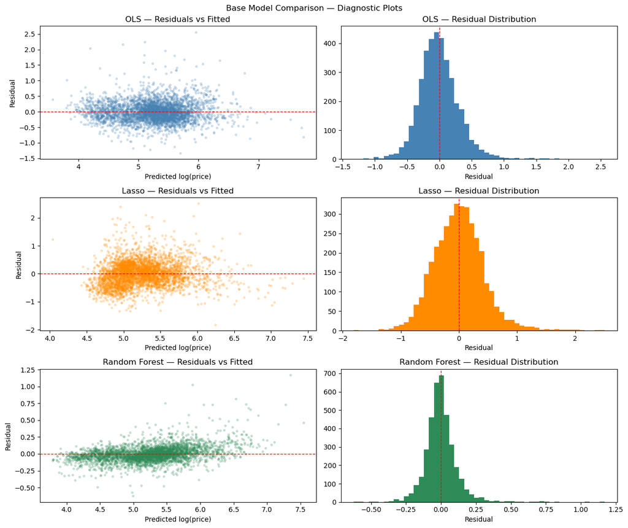

```python
# Residual diagnostic plots — OLS, Lasso, Random Forest
models_plot = [
    ('OLS',           y_pred_ols_train,   'steelblue'),
    ('Lasso',         y_pred_lasso_train, 'darkorange'),
    ('Random Forest', y_pred_rf_train,    'seagreen'),
]

fig, axes = plt.subplots(3, 2, figsize=(13, 11))
for row, (name, y_pred, color) in enumerate(models_plot):
    res = y_train - y_pred
    axes[row, 0].scatter(y_pred, res, alpha=0.2, s=8, color=color)
    axes[row, 0].axhline(0, color='red', linestyle='--', linewidth=1)
    axes[row, 0].set_xlabel('Predicted log(price)')
    axes[row, 0].set_ylabel('Residual')
    axes[row, 0].set_title(f'{name} — Residuals vs Fitted')
    axes[row, 1].hist(res, bins=50, color=color, edgecolor='none')
    axes[row, 1].axvline(0, color='red', linestyle='--', linewidth=1)
    axes[row, 1].set_xlabel('Residual')
    axes[row, 1].set_title(f'{name} — Residual Distribution')

plt.suptitle('Base Model Comparison — Diagnostic Plots', fontsize=12)
plt.tight_layout()
plt.show()
```

**Comment on residual diagnostic plot**

- *OLS and Lasso*

Show a similar pattern: residuals are not evenly spread around zero, there is a slight fan shape, where errors are larger for higher-priced listings. This is expected for a linear model predicting log-price on a dataset with many extreme values. Both models also have heavier tails in the residual distribution compared to Random Forest.

- *Random Forest*

Has much tighter residuals on the training set, ideally being zero in many cases. This confirms that it is fitting the training data very closely. While this looks impressive on training data, the higher gap between train MAPE and CV MAPE (seen in the comparison table) confirms that this tight fit does not fully carry over to unseen listings.

Overall, the diagnostic plots confirm that the linear models are slightly underfitting (missing price patterns they cannot express as straight lines), while Random Forest is overfitting on training data. Despite of that, with the impressive error in training data, we decided to choose Random Forest as a best-perfored model until now.

#### 3. Model Training and Hyperparameter Tuning

**a. Pipeline Hyperparameter tunning for 3 models**

```python
from sklearn.pipeline import Pipeline
from sklearn.preprocessing import RobustScaler
from sklearn.linear_model import LinearRegression, Lasso
from sklearn.ensemble import RandomForestRegressor
from sklearn.model_selection import GridSearchCV, cross_validate
from sklearn.metrics import mean_absolute_percentage_error, r2_score
import warnings
warnings.filterwarnings('ignore')

# Pipeline definition creation
'''
Linear models: RobustScaler (resistant to outliers) + model
Random Forest: no scaling needed (tree splits are scale-invariant)`
'''
ols_pipe = Pipeline([('scaler', RobustScaler()), ('model', LinearRegression())]) # OLS pipline
lasso_pipe = Pipeline([('scaler', RobustScaler()), ('model', Lasso(max_iter=20000))]) # Lasso pipiline
rf_pipe = Pipeline([('model', RandomForestRegressor(random_state=42, n_jobs=-1))]) # Random Forest pipiline

# Create hyperparameter grids
ols_grid = {'model__fit_intercept': [True, False]}

lasso_grid = {'model__alpha': np.logspace(-4, 1, 40).tolist()}

rf_grid = {
    'model__n_estimators'  : [100, 300, 500],
    'model__max_depth'     : [10, 20, None],
    'model__min_samples_leaf': [1, 4],
    'model__max_features'  : ['sqrt', 0.5],
}

# GridSearchCV (5-fold, scored by MAPE)
searches = {
    'OLS'          : GridSearchCV(ols_pipe,   ols_grid,   cv=5, scoring='neg_mean_absolute_percentage_error', n_jobs=-1),
    'Lasso'        : GridSearchCV(lasso_pipe, lasso_grid, cv=5, scoring='neg_mean_absolute_percentage_error', n_jobs=-1),
    'Random Forest': GridSearchCV(rf_pipe,    rf_grid,    cv=5, scoring='neg_mean_absolute_percentage_error', n_jobs=-1),
}

for name, gs in searches.items():
    gs.fit(X_train, y_train)
    print(f'{name}')
    print(f'  Best params : {gs.best_params_}')
    print(f'  Best CV MAPE: {-gs.best_score_:.4f}\n')

# Performance table: train vs CV (MAPE & R²)
tuned_results = {}
best_estimators = {}
for name, gs in searches.items():
    best = gs.best_estimator_
    best_estimators[name] = best
    y_pred_train = best.predict(X_train)
    cv_res = cross_validate(
        best, X_train, y_train, cv=5,
        scoring=['neg_mean_absolute_percentage_error', 'r2']
    )
    tuned_results[name] = {
        'Train MAPE': round(mean_absolute_percentage_error(y_train, y_pred_train), 4),
        'CV MAPE'   : round(-cv_res['test_neg_mean_absolute_percentage_error'].mean(), 4),
        'Gap (overfit?)': round(
            mean_absolute_percentage_error(y_train, y_pred_train)
            - (-cv_res['test_neg_mean_absolute_percentage_error'].mean()), 4),
        'Train R²'  : round(r2_score(y_train, y_pred_train), 4),
        'CV R²'     : round(cv_res['test_r2'].mean(), 4),
    }

results_df = pd.DataFrame(tuned_results).T
print('Tuned Model Comparison — MAPE & R² (5-fold CV)')
display(results_df)
print('Note: Gap = Train MAPE − CV MAPE. Negative gap → overfitting (train much better than CV).')
print('      Gap near 0 → good generalisation. Positive gap → underfitting.')
```

| Model | Best hyperparameters | Best CV MAPE |
| --- | --- | --- |
| **OLS** | `fit_intercept = False` | 0.0462 |
| **Lasso** | `alpha = 0.0001` | 0.0462 |
| **Random Forest** | `n_estimators = 500`, `max_depth = None`, `min_samples_leaf = 1`, `max_features = 0.5` | 0.0398 |

**Comment and interpretation after tunning hyperparameter**

*OLS (Linear Regression)*

However, the CV R² of 0.69 tells us that OLS can only explain about 70% of the variation in listing price using a linear combination of features. Given that price depends on complex interactions. A private room in a beachfront suburb is not simply "location effect + room type effect" added together — this ceiling is expected. OLS is doing the best it can within its structural limits.

*Lasso*

The best alpha found by cross-validation was 0.000, a very small value close to zero. This is a key finding: when alpha is near zero, the L1 penalty is barely active, and Lasso reduces almost entirely to OLS. This explains why both models' CV MAPE and R² are nearly identical.

What this tells us is that in this dataset, the problem is not that we have too many noisy features pulling the model in wrong directions. It is that the relationship between features and price is genuinely non-linear, which no amount of coefficient shrinkage can fix. Lasso's intended benefit (removing weak features) had almost no effect here because most features are contributing some signal, just not in a linear way.

The gap for Lasso (Train MAPE − CV MAPE ≈ 0.00) is similarly small, confirming there is no meaningful overfitting, but both models generalise predictably, just not very accurately.

*Random Forest*

Random Forest improve but not too significantly

Importantly, even with this overfitting, the CV MAPE of Random Forest is still lower than both OLS and Lasso, but not significantly. This means that despite memorising too much of the training data, Random Forest still captures enough genuine price patterns to outperform the linear models on new listings. This makes it the strongest of the three initial models.

The CV R² of 0.749 further confirms this — Random Forest explains 74.9% of price variation on held-out data, compared to 69.6% for OLS/Lasso.

> The results point to a clear conclusion: the relationship between listing features and price is non-linear, which the two linear models structurally cannot handle regardless of tuning. Random Forest is the natural next step, though its overfitting leaves room for improvement, which motivates the move to boosting models (XGBoost, CatBoost) in Section 5.

### Notice:

- The below version is the very initial version we run the model with `basically original 26 variables` as base assignment requirements:

**Comment perfomance**

Our first Kaggle submission using the tuned Random Forest achieved a low public leaderboard score of 0.64. This reflects the model's ability to pick up non-linear patterns in the data, performing meaningfully better than the linear baselines. The fact that we just use only 26 initial features so that it was limited by overfitting on the training set because some of beginning features are uncapable to explain further the target. The most difficult listings to predict were amentities strings to define which properties in less or more common, or which neighborhood suburn are highly prefered to rent, where our team ignore them for the first time.

#### 5. Model Improvement and Reflection

**a. Feature re-selection:**

Our first model used only the original 26 variables. After reviewing which features were driving predictions, we rebuilt the feature set with several targeted improvements:

**b. Tunning hyperparameter**

- Given that price data contains outliers and non-linear patterns, the priority was not maximising fit on the training set but closing the gap between training and cross-validation error. Tuning regularisation-related parameters. We mannually set low range of depth limits and leaf size to directly addresses the overfitting observed in the initial model.

**Random Forest Grid — Justification (overfitting-focused)**

| Hyperparameter | Values | Role | Why chosen (overfitting context) |
| --- | --- | --- | --- |
| `n_estimators` | 100, 300, 500 | Number of trees | More trees reduce variance and stabilise predictions; does not itself cause overfitting (bagging averages over trees). |
| `max_depth` | 10, 20, None | Tree depth | Main lever against overfitting, capping depth stops fully-grown trees from memorising the training data, aiming to minimize the max depth |
| `min_samples_leaf` | 1, 4 | Min samples per leaf | Larger leaves smooth predictions and resist price outliers, narrowing the train–CV gap. |
| `max_features` | 'sqrt', 0.5 | Features per split | Fewer features decorrelate the trees, increasing diversity and lowering variance. |

#### **Justify why these varibles is effective**

- neighbourhood_te (rank 6): the target-encoded location carries genuine signal.
- has_pool (rank 16): an amenity binary makes the list, showing that extracting individual binaries captures value that amenities_count alone cannot.
- bath_to_bedroom_ratio (rank 18): the engineered ratio is being used by the model.
- host_acceptance_rate (rank 19): usable once converted from a percentage string to a numeric value.

→ This is direct evidence that the feature re-selection produced usable signal. After re-selection, the engineered features all appear in the top-20 MDI, indicating that they contribute meaningfully to the model's decisions. Importance is also more evenly distributed (the leading feature falls from 0.30 to 0.175), reducing the model's reliance on any single variable. That said, MDI only reflects how much a feature is used, not how well the model predicts; the effectiveness of the improvement is confirmed by the average score achieved on the Kaggle test-set submission.

- Features that possibly drive price (feature importance): size and location remain at the top in both versions (room_type, accommodates, bedrooms, bathrooms, dist_to_cbd) — a consistent and credible result. These variables can serve as a basis for decision-making, and warrant deeper exploration to extract additional predictive gains.

**c. Main limitation preventing a higher ranking**

- *Persistent overfitting:* Despite tuning, our training MAPE remains noticeably lower than the cross-validated error. Tree-based models learn the training listings in fine detail, and with only ~3,700 training rows, some of that detail is noise rather than real pattern. Stronger regularisation (shallower trees, larger minimum leaf size) partially addresses this but cannot eliminate it entirely.
- *Review text was not used:* A top ranking might require richer inputs in reality, for example, we could have using sentimental analysis to analyse text and description of listings. This was a conscious trade-off given lack of in-depth understanding but represents a meaningful missed signal.

And some significant correlation between features and price we're missing during the feature prrocess.

- *Neighbourhood encoding ceiling*: Even with KFold target encoding, suburbs with very few listings produce unreliable encoded values. Sparse suburbs effectively fall back to the global mean, losing local price information. So that we are unable to capture the full feature relationship in-depth.

**c. Extension model set: XGBoost and CatBoost**

```python
from sklearn.ensemble import RandomForestRegressor
from xgboost import XGBRegressor
# import catboost
from catboost import CatBoostRegressor
from sklearn.metrics import mean_squared_error
```

```python
# 1. BASELINE BENCHMARK
from sklearn.model_selection import RandomizedSearchCV, cross_val_score

print("Baseline CV MAPE (5-fold):")
baseline = {
    'Random Forest': RandomForestRegressor(n_estimators=100, random_state=42),
    'XGBoost'      : XGBRegressor(n_estimators=200, random_state=42, verbosity=0),
    'CatBoost'   : CatBoostRegressor(n_estimators=200, random_state=42, verbose=0)
}
for name, model in baseline.items():
    scores = cross_val_score(model, X_train, y_train, cv=5,
                             scoring='neg_mean_absolute_percentage_error', n_jobs=-1)
    print(f"  {name}: {-scores.mean():.4f} ± {scores.std():.4f}")

# 2. HYPERPARAMETER TUNING
tree_param_distributions = {
    'n_estimators'    : [100, 200, 300, 500],
    'max_depth'       : [10, 20, 30, None],
    'max_features'    : ['sqrt', 'log2', 0.5, 0.8],
    'min_samples_split': [2, 5, 10],
    'min_samples_leaf': [1, 2, 4, 8]
}

# Expanded XGBoost grid — more trees + regularisation params
xgb_gs = RandomizedSearchCV(
    XGBRegressor(objective='reg:absoluteerror', eval_metric='mape', random_state=42, verbosity=0, tree_method='hist'),
    param_distributions={
        'n_estimators'    : [300, 500, 1000, 2000],
        'max_depth'       : [3, 4, 6, 8],
        'eta'             : [0.005, 0.01, 0.05, 0.1],
        'subsample'       : [0.6, 0.7, 0.8, 0.9, 1.0],
        'colsample_bytree': [0.5, 0.7, 0.8, 1.0],
        'min_child_weight': [1, 3, 5, 10],
        'reg_alpha'       : [0, 0.01, 0.1, 1.0],
        'reg_lambda'      : [0.5, 1.0, 2.0, 5.0],
    },
    n_iter=30, cv=5, scoring='neg_mean_absolute_percentage_error',
    n_jobs=-1, random_state=42
)

rf_rs = RandomizedSearchCV(
    RandomForestRegressor(random_state=42, criterion='absolute_error'),
    param_distributions=tree_param_distributions,
    n_iter=20, cv=5, scoring='neg_mean_absolute_percentage_error', n_jobs=-1, random_state=42
)

cat_rs = RandomizedSearchCV(
    CatBoostRegressor(loss_function='MAPE', random_state=42, verbose=0),
    param_distributions={
        'depth'          : [4, 6, 8, 10],
        'l2_leaf_reg'    : [1, 3, 5, 7, 9],
        'learning_rate'  : [0.01, 0.03, 0.05, 0.1, 0.2],
        'iterations'     : [200, 300, 500, 1000]
    },
    n_iter=20, cv=5, scoring='neg_mean_absolute_percentage_error', n_jobs=-1, random_state=42
)

for search in [xgb_gs, rf_rs, cat_rs]:
    search.fit(X_train, y_train)

print("\nTuning Results:")

print("Model: XGBooost\n")
print(f"Best Params: {xgb_gs.best_params_}\n")
print(f" CV MAPE: {-xgb_gs.best_score_:.4f}\n")

print("Model: Random Forest\n")
print(f"Best Params: {rf_rs.best_params_}\n")
print(f" CV MAPE: {-rf_rs.best_score_:.4f}\n")

print("Model: CatBoost\n")
print(f"Best Params: {cat_rs.best_params_}\n")
print(f" CV MAPE: {-cat_rs.best_score_:.4f}\n")
```

[output not shown]

### Feature importance analysis

**a. Feature importance with Random Forecast**

```python
# RF model is inside the Pipeline under step name 'model'
rf_model = best_estimators['Random Forest'].named_steps['model']

# MDI Feature Importance (built-in to RF)
importances = pd.Series(rf_model.feature_importances_, index=X_train.columns)
top20 = importances.nlargest(20).sort_values()

fig, ax = plt.subplots(figsize=(9, 7))
top20.plot(kind='barh', color='steelblue', ax=ax)
ax.set_title('Random Forest — Top 20 Feature Importances (MDI)', fontsize=12)
ax.set_xlabel('Mean Decrease in Impurity (MDI)')
ax.axvline(importances.mean(), color='red', linestyle='--',
           linewidth=1, label=f'Mean importance ({importances.mean():.4f})')
ax.legend(fontsize=9)
plt.tight_layout()
plt.show()

# Summary table
imp_table = (
    importances
    .sort_values(ascending=False)
    .reset_index()
    .rename(columns={'index': 'Feature', 0: 'Importance'})
    .head(20)
    .reset_index(drop=True)
)
imp_table.index += 1
print('Top 20 features by MDI importance:')
display(imp_table)
```

[output not shown]

#### **Comment**

- *Listing property type:* strongest signal

Airbnb Pricing significantly influenced on the two room variables: Entire room/ apt and private room. This may suggest that whether a guest rents an entire property or a single room is the strongest determinant of price.

- *Capacity*: core pricing signal

This categories is consistently matched with correlation heatmap show above, we can confirm their linear realationship between them and price, indicating that listing scale is a core pricing signal. `accommodates`, `bedrooms`, `bathrooms`, and `beds` all rank highly, with the engineered `bath_to_bedroom_ratio` also entering the list.

- *Location*: strong and consistently engineered

One again, location is the next major driver when mostly engineered variables like target-encoded `neighbourhood` and `dist_to_cbd` contributes meaningfully.

- *Host, availability, and amenity features*

`Host_listings_count`, `host_experience_days`, and `host_acceptance_rate` capture host professionalism and behaviour; `availability_rate` and `availability_30` reflect booking pressure; and among amenities, the engineered has_pool and amenities_count both earn places, this is evidence that extracting individual high-value amenities adds value beyond a simple count.

> **Trade-off here: between host and guests**

MDI measures how frequently and how cleanly a feature is used in tree splits. It does not tell us the direction of the effect or whether the feature is the true cause of price differences. When two features are correlated (e.g. bedrooms and accommodates), importance can be split unevenly between them, making one appear less influential than it really is. The scores here should be read as a guide to which features the model found useful, not as a definitive ranking of real-world pricing drivers.

**b. Extension: SHAP feature selection for XGBoost and CatBoost**

```python
# import shap

# # TreeExplainer is exact and fast for XGBoost
# explainer   = shap.TreeExplainer(xgb_gs.best_estimator_)
# shap_values = explainer.shap_values(X_train)

# # Mean absolute SHAP = model-wide feature importance
# shap_imp = pd.Series(
#     np.abs(shap_values).mean(axis=0),
#     index=X_train.columns
# ).sort_values(ascending=False)

# # Plot 1: mean |SHAP| bar chart
# fig, ax = plt.subplots(figsize=(10, 9))
# shap_imp.head(50).sort_values().plot.barh(ax=ax, color='steelblue')
# ax.set_title('XGBoost — Top 50 Features by Mean |SHAP|', fontsize=12)
# ax.set_xlabel('Mean |SHAP value|  (impact on log-price)')
# plt.tight_layout()
# plt.show()

# # Select top 50
# top50_shap = shap_imp.nlargest(50).index.tolist()
# print(f"Top 50 features by SHAP importance:")
# display(shap_imp.head(50).reset_index().rename(
#     columns={'index': 'Feature', 0: 'Mean |SHAP|'}).round(5))
```